# **Facial Emotion Detection**

## Submission by Alexander J Miller

# **Problem and Solution Summary**

- **Problem to be Solved**
  - Emotion detection has all sorts of applications, we are specifically interested in how recognition of facial expressions can assist in deception detection and information gain for law enforcement purposes. Facial expressions, among many other behaviors, can provide insight into what someone is thinking or feeling. Properly recognizing and reacting to such expressions can help law enforcement identify areas for follow up and recognize when they may not be getting the whole story.
  - As with may other tasks, humans are prone to bias and emotion which can influence their ability to recognize and react to behavioral queues (like facial expressions), for this reason a computer model could be a helpful tool in the consistent and effective identification of such behaviors.
  - Such a tool could function as a 'gut check' or a second opinion in addition to helping identify details/behaviors an individual may have missed
- **Proposed Solution**
  - This project serves as a proof of concept to show that computers are capable of such tasks by proving they are capable of detecting 4 basic emotions: happy, sad, neutral and surprise.
  - We have designed and trained a convolutionl neural network to classify images of faces. The model was able to achieve 83% accuracy on the given test data, and this can very likely be improved upon.
  - almost all models had gret difficulty exceeding 70% - 75% accuracy on the test data. Data augmentation was vital in getting the accuracy over 80%, indicating greater data/diversity would be substantially beneficial
  - precision was the lowest for 'neutral' images at 73%, and recall was the lowest for 'sad' images at 71%.
  - the final model consisted of 58 layers: 32 convolutional layers, a flatten layer, 24 ANN lyers and an output layer
  - for the most part the CNN consisted of repeated 'substructures' of the following form:

    model.add(Conv2D([# of filters], ([kernal size]), padding="same", activation = 'relu'))

    model.add(BatchNormalization())

    model.add(LeakyReLU(0.1))

    model.add(MaxPooling2D(pool_size=(2, 2)))

    model.add(Dropout(.2))
  - most of the ANN consisted of repeated 'substructures' of the following form:

    model.add(Dense([# of nodes], activation = 'relu'))

    model.add(BatchNormalization())

    model.add(LeakyReLU(0.1))

    model.add(Dropout(.2))
  - these substructures provided a manageable/organized way to add complexity to the model without having to fret over ll the different sorts of changes that could be made. However, this overreliance on the 'substructure' strategy also provides an area for further exploration as there is no reason to assume this is the most effective strategy, it was merely convenient for building the models

# **Executive Summary**

- **Key Takeaways**
  - Based on the findings in the following notebook it is clear that effective facial emotion recognition by a CNN is very possible.
  - the best model we were able to implement (cnn_model_3c2) achieved an accuracy of 83% on the provided test data, this can almost certainly be improved upon with further experimentation.
  - transfer learning attempts proved ineffective as the "learnings" of the trained models did not seem to carry over well to our specific use case. We tested the VGG16, ResNet and EfficientNet pre-trained models. Performance was poor, but this does not rule out the possibility that other pre-trained models exist which could prove effective at emotion recognition.
  - there is a clear need for more data (i.e. more images). Any emotion has a diverse spectrum regarding how it may appear or be exhibited by an individual. To combat this there is a need for more images, the more images we have the more likely we are to capture the full spectrum of the many ways any one emotion may be exhibited.
- **Next Steps**
  - procure more images! Access to the 420,000+ images of the AffectNet database could be immensely helpful (http://mohammadmahoor.com/affectnet/); however, access has to be requested and granted (and seems to be reserved for students, professors, or lab managers). There are certainly other databases worth exploring as well
  - further emotions need to be added to the model/data. Anger, disgust and fear are crutial emotions that can be very informative. These would need to be added to any model designed to assist in deception detection and information gathering
  - the model needs to then be implemented to utilize a video feed as opposed to being fed individual images
  - finally, to be maximally useful, our model should be able to identify behaviors that go beyond facial emotions. Behaviors like touching the face, swallowing, pausing and failing to answer questions can all be very informative. They go well beyond the scope of this project, but identifying such behaviors would be significant and could go a long way to assist in deception detection and information gain.

# **Recommendations for Implementation**

- **Key Risks**
  - the model is able to recognize emotions only, it is unable to make any judgements about what they may mean or take their context into account
  - this model is intended to **assist** with information gathering and deception detection, it is a tool to be utilized by an experienced professional who should exercise their own judgement accordingly
- **Implementation**
  - Microsoft Azure has an array of services available specifically for housing and training machine learning models.
  - they will store 1,000 faces for \$.01 per month
  - they have an API platform for deep learning applications geared towards working with facial images charging:

  0-1M transactions - \$1 per 1,000 transactions

  1-10M transactions - \$0.65 per 1,000 transactions

  10-100M transactions - \$0.60 per 1,000 transactions

  100M+ transactions - \$0.40 per 1,000 transactions
  - pricing is application specific and a proper quote would need to be obtained for more accurate pricing depending on the model's implementation (https://azure.microsoft.com/en-us/pricing/details/cognitive-services/)
- **Further Analysis**
  - there is still a significant amount of experimentation to be performed in order to improve the model.
  - We have barely scratched the surface of all sorts of parameters. For instance activation functions were barely tweaked and loss functions were never altered. Batch sizes were never adjusted nor were step sizes.
  - checkpoints should be utilized going forward! Checkpoints can be used to save the best performing models, which is imperative as I have lost models due to Colab timing out! This will also help with identifying the best models over a series of epochs, currently I have am left with single model after training over a given number of epochs. This means I could be missing out on better models if they occur during the training period (such models would be lost but checkpoints would be able to identify and save such models)
  - the numer of epochs to train over should also be experimented with. The best model was trained for 75 epochs on original images and then 75, 75 and 100 epochs on augmented images. These numbers were arbitrary and should be tweaked to see what gives the best performance. I also trained the model for 40 epochs on original images and then groups of 40 epochs on augmented images, getting up to 320 epochs. However, thi number of epochs seems to have been too low for meaningful learning to take place fir a given dataset and accuracy on validation data (once again) capped out around 70% - 75%.
  - an effort should be made to add images to our datasets. The alternative dataset I utilized (from kaggle) had a substantial amount of overlap with the provided dataset, but there were still 5,000 or so unique images that coud have been utilized and were not. Moreover, there are plenty of repositories for labeled facial expression images o the internet that are worth looking into.
  - More images coud have a substantial impact on image accuracy. It seems that the difficulty in exceeding 70% - 75% accuracy on the validation data is simply because any single emotion has a very diverse number of possible apperances. Data augmentation helped to add some variation into our dataset (and capture some of this diversity), but additional images would be far more valuable!
  - As mentioned above, adjusting the model to utilize a video feed and identifying actions like touching the face, swallowing and coughing would be an important avenue to explore for the next iteration of a model to identify deception and facilitate information gathering.

## **Problem Definition**

**The context:** Why is this problem important to solve?

- a model that can detect facial emotions could give us insight into how people are feeling or what they might be thinking. This could be used to gauge how people respond to products, ads, sales pitches, etc. In our case, emotion recognition to assist law enforcement with deception detection and information gathering is the specific use case we are interested in.

**The objectives:** What is the intended goal?

- given an image of a face have a model correctly classify the face as happy, sad, neutral or surprised

**The key questions:** What are the key questions that need to be answered?

- what are the distinguishing characteristics of each emotion? Can a model recognize these?
- is our data optimal? do imperfections exist like duplicate or mislabeled images?

**The problem formulation:** What are we trying to solve using data science?

- this is a supervised learning, classification problem with 4 classes
- using convolutional neural networks we will attempt to create a model that can correctly identify and classify happy, sad, neutral and surprised faces.

## **About the dataset**

The data set consists of 3 folders, i.e., 'test', 'train', and 'validation'. Each of these folders has four subfolders:

**‘happy’**: Images of people who have happy facial expressions.  
**‘sad’**: Images of people with sad or upset facial expressions.  
**‘surprise’**: Images of people who have shocked or surprised facial expressions.  
**‘neutral’**: Images of people showing no prominent emotion in their facial expression at all.

## **Mounting the Drive**

**NOTE:** Please use Google Colab from your browser for this notebook. **Google.colab is NOT a library that can be downloaded locally on your device.**

```python
# Mounting the drive
from google.colab import drive
drive.mount('/content/drive')
```

## **Importing the Libraries**

```python
# for accessing the datasets
import zipfile
import os

# for utilizing and visualizing the datasets
import matplotlib.pyplot as plt
import numpy as np
import pandas as pd
import seaborn as sns
from tensorflow.keras.preprocessing.image import load_img, img_to_array, ImageDataGenerator

# Importing Deep Learning Libraries
import tensorflow as tf
#from tensorflow.keras.preprocessing.image import ImageDataGenerator
from tensorflow.keras.layers import Dense, Input, Dropout, GlobalAveragePooling2D, Flatten, Conv2D, BatchNormalization, Activation, MaxPooling2D, LeakyReLU
from tensorflow.keras.models import Model, Sequential
from tensorflow.keras.optimizers import Adam, SGD, RMSprop

# importing existing models for transfer learning
from keras.applications.vgg16 import VGG16
import tensorflow.keras.applications as ap

#for setting random seed and clearing backend
from tensorflow.keras import backend
import random
random_seed_val = 42  # random seed value is to be used for the entire notebook

#to produce classification report for the accuracy of a model
from sklearn import metrics

# turn off warnings
import warnings
warnings.filterwarnings("ignore")
```

```python
# install imagehash - you won't need to run this line if you already have imagehash installed,
!pip install imagehash

# load imagehash - we will need this module to hash our images (in order to check for duplicates)
import imagehash
```

```
     ━━━━━━━━━━━━━━━━━━━━━━━━━━━━━━━━━━━━━━ 296.5/296.5 kB 12.4 MB/s eta 0:00:00
```

### **Let us load and unzip the data**

**Note:**

- You must download the dataset from the link provided on Olympus and upload the same on your Google drive before executing the code in the next cell.
- In case of any error, please make sure that the path of the file is correct as the path may be different for you.

```python
# Storing the path of the data file from the Google drive
path = '/content/drive/MyDrive/MIT_DataScience/Capstone Project/Facial_emotion_images.zip'

# The data is provided as a zip file so we need to extract the files from the zip file
with zipfile.ZipFile(path, 'r') as zip_ref:
    zip_ref.extractall()
```

```python
# set data folder path so it can be easily referenced
folder_path = "Facial_emotion_images/"
```

```python
# create dataframe to store images and relevant features
image_df = pd.DataFrame(columns = ['emotion', 'data type', 'path', 'image','image hash','pixel data rgb','pixel data gray'])

counter = 0

data_type_path = os.listdir(folder_path)

# get each data type folder (ie. training, validation, test)
for data_type in data_type_path:
  emotion_type_path = os.listdir(folder_path + data_type )
  # get each emotion type folder (ie. happy, sad, neutral, surprise)
  for emotion in emotion_type_path:
    image_path = os.listdir(folder_path +  data_type + '/' + emotion)
    for face_image in image_path:
      # get the path for an individual image
      path_of_image = folder_path + data_type +'/'+  emotion + '/' + face_image

      # load the image, as color and grayscale image
      img_rgb = load_img(folder_path + data_type +'/'+  emotion + '/' + face_image, color_mode='rgb')
      img_gray = load_img(folder_path + data_type +'/'+  emotion + '/' + face_image, color_mode='grayscale')

      # this will assign a unique hash to every image (which we will use to check for duplicates)
      image_hash = imagehash.average_hash(img_gray)

      #convert color and grayscale images into separate pixel arrays
      pixel_array_rgb = img_to_array(img_rgb)
      pixel_array_gray = img_to_array(img_gray)

      # add path, emotion type and data type into a dataframe
      image_df = image_df.append({'emotion' : emotion, 'data type' : data_type, 'path' : path_of_image,"image":img_rgb,'image hash':image_hash, 'pixel data rgb':pixel_array_rgb, 'pixel data gray':pixel_array_gray},ignore_index = True)
```

## **Exploratory Data Analysis & Data Preparation**

```python
# preview of the data
image_df
```

|  | emotion | data type | path | image | image hash | pixel data rgb | pixel data gray |
| --- | --- | --- | --- | --- | --- | --- | --- |
| 0 | neutral | test | Facial_emotion_images/test/neutral/7397.jpg | <PIL.Image.Image image mode=RGB size=48x48 at ... | 3f3f030b6f030307 | [[[83.0, 83.0, 83.0], [85.0, 85.0, 85.0], [89.... | [[[83.0], [85.0], [89.0], [90.0], [88.0], [86.... |
| 1 | neutral | test | Facial_emotion_images/test/neutral/7414.jpg | <PIL.Image.Image image mode=RGB size=48x48 at ... | 3d7f1a1a6e27060c | [[[122.0, 122.0, 122.0], [78.0, 78.0, 78.0], [... | [[[122.0], [78.0], [87.0], [92.0], [86.0], [55... |
| 2 | neutral | test | Facial_emotion_images/test/neutral/7316.jpg | <PIL.Image.Image image mode=RGB size=48x48 at ... | fc6636befe3e0c29 | [[[153.0, 153.0, 153.0], [163.0, 163.0, 163.0]... | [[[153.0], [163.0], [173.0], [181.0], [192.0],... |
| 3 | neutral | test | Facial_emotion_images/test/neutral/7391.jpg | <PIL.Image.Image image mode=RGB size=48x48 at ... | 7f182eee6e262c04 | [[[60.0, 60.0, 60.0], [64.0, 64.0, 64.0], [77.... | [[[60.0], [64.0], [77.0], [105.0], [147.0], [1... |
| 4 | neutral | test | Facial_emotion_images/test/neutral/7422.jpg | <PIL.Image.Image image mode=RGB size=48x48 at ... | 1c3c1f073f1f1f0e | [[[151.0, 151.0, 151.0], [137.0, 137.0, 137.0]... | [[[151.0], [137.0], [138.0], [86.0], [2.0], [3... |
| ... | ... | ... | ... | ... | ... | ... | ... |
| 20209 | sad | validation | Facial_emotion_images/validation/sad/22631.jpg | <PIL.Image.Image image mode=RGB size=48x48 at ... | e0e0c0d0f070e0e2 | [[[56.0, 56.0, 56.0], [64.0, 64.0, 64.0], [74.... | [[[56.0], [64.0], [74.0], [106.0], [144.0], [1... |
| 20210 | sad | validation | Facial_emotion_images/validation/sad/24909.jpg | <PIL.Image.Image image mode=RGB size=48x48 at ... | 1e3e1b3f3e0e0e0c | [[[29.0, 29.0, 29.0], [17.0, 17.0, 17.0], [26.... | [[[29.0], [17.0], [26.0], [25.0], [10.0], [9.0... |
| 20211 | sad | validation | Facial_emotion_images/validation/sad/9548.jpg | <PIL.Image.Image image mode=RGB size=48x48 at ... | 3e04073f1f8bc7c3 | [[[30.0, 30.0, 30.0], [23.0, 23.0, 23.0], [18.... | [[[30.0], [23.0], [18.0], [16.0], [22.0], [75.... |
| 20212 | sad | validation | Facial_emotion_images/validation/sad/23483.jpg | <PIL.Image.Image image mode=RGB size=48x48 at ... | 7c7cf07c7c343018 | [[[18.0, 18.0, 18.0], [19.0, 19.0, 19.0], [19.... | [[[18.0], [19.0], [19.0], [35.0], [13.0], [48.... |
| 20213 | sad | validation | Facial_emotion_images/validation/sad/29561.jpg | <PIL.Image.Image image mode=RGB size=48x48 at ... | c0003c381a3ffef8 | [[[64.0, 64.0, 64.0], [55.0, 55.0, 55.0], [71.... | [[[64.0], [55.0], [71.0], [84.0], [73.0], [113... |

20214 rows × 7 columns

**Observations:**

- we can see there are 20214 images in total
- note that emotion labels will need to be converted to numerical values so they can be one-hot encoded

#### **Are all images the same size?**

```python
#create a new column with color image shapes so we can easily determine if all images are the same size
image_shapes = []
for image in image_df['pixel data rgb']:
  image_shapes.append(image.shape)

image_df['rgb image shape'] = image_shapes
```

```python
# check for unique image shapes
image_df['rgb image shape'].unique()
```

```
array([(48, 48, 3)], dtype=object)
```

**Observation:**

- All images are 48x48 pixels

#### **Are all images grayscale?**

```python
# loop through every pixel of every image (rgb format) to check that R = G = B for every pixel in the dataset (this will confirm that all images are grayscale)
image_num = 0
greyscale=True
for image in image_df['pixel data rgb']:
  for row in image:
    for pixel in row:
      if (pixel[0] == pixel[1] == pixel[2]) != True:
        #this will print out the path to any image that contains colored pixels
        print(image_df['path'][image_num])
  image_num +=1
print("All images are greyscale:", greyscale)
```

```
All images are greyscale: True
```

**Observation:**

- All images are grayscale images

#### **Are there duplicate images?**

```python
#check for duplicate images
image_df['image hash'].duplicated().sum()
```

```
1146
```

```python
# dropping all duplicate values based on repeat hashcodes
image_df.drop_duplicates(subset="image hash",keep=False, inplace=True)
image_df.shape
```

```
(18124, 7)
```

**Observations:**

## **Visualizing our Classes**

Let's look at our classes.

**Write down your observation for each class. What do you think can be a unique feature of each emotion, that separates it from the remaining classes?**

```python
# set the size for an image
picture_size = 48

# define a function to display 9 images (in the training set) of a given emotion
def displayImageSample(expression):
  plt.figure(figsize= (8,8))
  for i in range(1, 10, 1):
      plt.subplot(3, 3, i)

      #load the image
      img = load_img(folder_path + "train/" + expression + "/" + os.listdir(folder_path + "train/" + expression)[i], target_size = (picture_size, picture_size))

      # remove tickmarks and text
      ax = plt.gca()
      ax.tick_params('y', labelleft=False)
      ax.tick_params('x', labelbottom=False)
      ax.set_xticks(ticks=[])
      ax.set_yticks(ticks=[])
      plt.imshow(img)

  plt.show()
```

### **Happy**

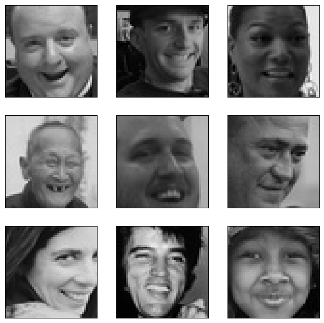

```python
# display nine images labeled 'happy' (from the training set)
displayImageSample('happy')
```

**Observations and Insights: happy**

- faces depicted in these images tend to show teeth and tend to squint due to raised cheeks
- the corners of the mouth pull back towards the ears
- these features seem prominant enough that our model should be able to recognize them

### **Sad**

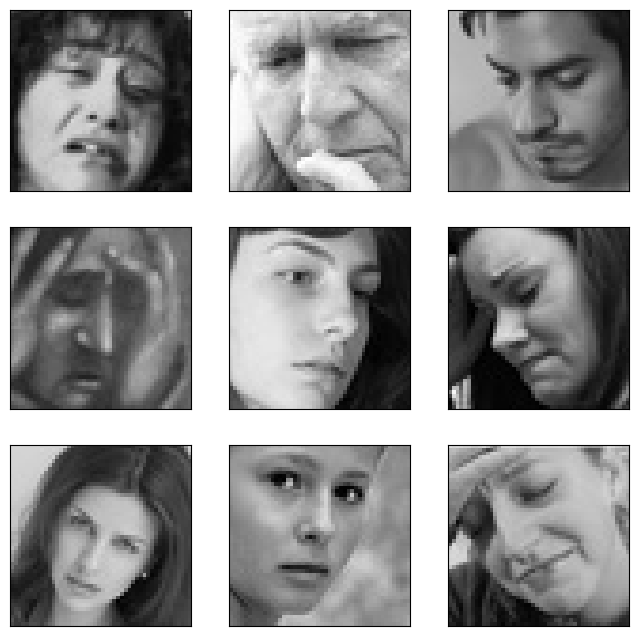

```python
# display nine images labeled 'sad' (from the training set)
displayImageSample('sad')
```

**Observations and Insights: sad**

- faces depicted tend to have a furrowed brow and outer eyebrows slanting downward
- subjects depicted seem to have a greater liklihood to 'avert their gaze' (look down or to the side) when compared to other emotions
- some face exhibit a classic 'frown,' but not all, suggesting this may be a misleading feature to look for
- features are more subtle and more diverse than happiness, suggesting it will be more difficult to correctly recognize sadness as an emotion

### **Neutral**

[figure not shown]

```python
# display nine images labeled 'neutral' (from the training set)
displayImageSample('neutral')
```

**Observations and Insights: neutral**

- this wil likely be the most difficult emotion to correctly identify
- there a few notable features, and it seems like the emotion is characterized moreso by a lack of distinguishable features
- some of these faces look anxious, sad or happy. Correctly identifying neutral faces might be difficult for any model (maybe even a human in some instances!) Alternatively, this could be evidence that some images are mislabeled!

### **Surprised**

[figure not shown]

```python
# display nine images labeled 'surprise' (from the training set)
displayImageSample('surprise')
```

**Observations and Insights: surprise**

- surprise is characterized by a wide open mouth, wide open eyes and raised eyebrows
- these features are very noticeable and differentiated from other emotions, suggeting this emotion should be easier for our model to recognize

## **Checking Distribution of Classes**

```python
# view emotion occurance by data type (ie. train, test, validation)
print(image_df.groupby('data type')['emotion'].value_counts())
```

```
data type   emotion
test        neutral       31
            sad           31
            happy         30
            surprise      19
train       happy       3856
            neutral     3783
            sad         3776
            surprise    2040
validation  happy       1770
            neutral     1175
            sad         1069
            surprise     544
Name: emotion, dtype: int64
```

```python
# before divvying up our dataframe, let's shuffle image_df to ensure emotion classes aren't grouped together during training
np.random.shuffle(image_df.values)

# create separate dataframes for each data type
train_data_df = image_df[image_df['data type'] == 'train']
validation_data_df = image_df[image_df['data type'] == 'validation']
test_data_df = image_df[image_df['data type'] == 'test']

print("training data shape:",train_data_df.shape)
print("validation data shape:",validation_data_df.shape)
print("test data shape:",test_data_df.shape)
```

```
training data shape: (13455, 7)
validation data shape: (4558, 7)
test data shape: (111, 7)
```

## **Visualizing Class Distributions**

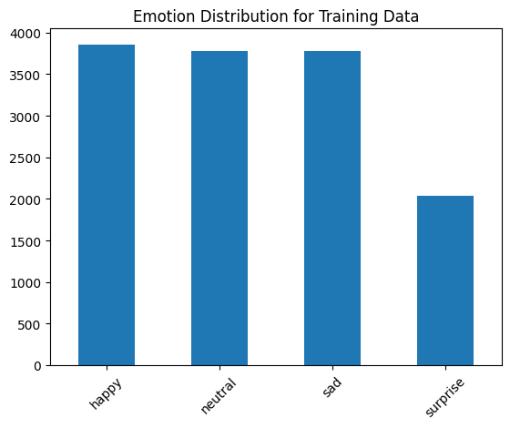

```python
# viusalize emotion occurance via bar chart, for the training dataset
train_data_df['emotion'].value_counts().plot(kind='bar')
plt.xticks(rotation=45)
plt.title('Emotion Distribution for Training Data')
plt.show()
```

**Observations & Insights - Training Data**

- for the training dataset each emotion has an average of 3,363 images
- happy is depicted the most with 3856 images, while surprise is depited the least with 2040 images

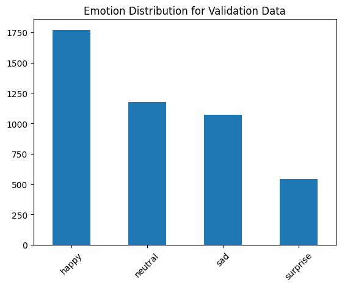

```python
# viusalize emotion occurance via bar chart, for the validation dataset
validation_data_df['emotion'].value_counts().plot(kind='bar')
plt.xticks(rotation=45)
plt.title('Emotion Distribution for Validation Data')
plt.show()
```

**Observations & Insights - Validation Data**

- the validation data shows the greatest range, with happiness depicted 1770 times and surprise depicted 544 times
- this is not ideal as happiness is overrepresented in the validation data and surprise is underrepresented
- it is probably worthwhile to drop happy images so that the validation data better resembles the class distributions of the training and test data

### **Reducing the Number of 'Happy' Images in the Validation Set**

we will reduce the number of 'happy' images in the validation set to 1122 (the mean of the number of sad and neutral images in the validation set)

```python
index_list = []
to_remove = 0

# get emotion column from validation_data_df and convert it to a numpy array
data = validation_data_df['emotion'].to_numpy()

# loop through array of emotions, record the index of the first 648 'happy' images
for i in range(0,len(data)):
  if data[i] == 'happy' and to_remove < 648:
    index_list.append(i)
    to_remove+=1
```

```python
# reset indecies of validation_data_df so that the dataframes' indecies line up with indecies in index_list
validation_data_df = validation_data_df.reset_index()
validation_data_df = validation_data_df.drop(index = index_list)
```

```python
#print new shape of validation_data_df
print(validation_data_df.shape)
```

```
(3910, 8)
```

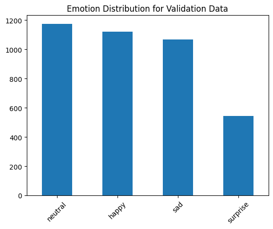

```python
# viusalize updated emotion occurance via bar chart, for the revised validation dataset
validation_data_df['emotion'].value_counts().plot(kind='bar')
plt.xticks(rotation=45)
plt.title('Emotion Distribution for Validation Data')
plt.show()
```

**Observations:**

- while this distribution still may not be perfect, it is difficult to say what they perfect or correct distribution should be. Given the data we have, the distribution of emotions in the validation set should resemble the train and test datasets well enough for our purposes

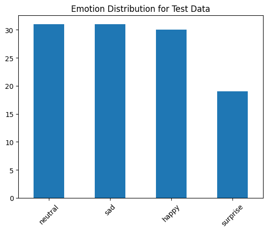

```python
# viusalize emotion occurance via bar chart, for the test dataset
test_data_df['emotion'].value_counts().plot(kind='bar')
plt.xticks(rotation=45)
plt.title('Emotion Distribution for Test Data')
plt.show()
```

**Observations & Insights - Test Data**

- happy, sad and neutral are featured in the test data in similar volumes
- there are noticably fewer 'surprise images,' but this is in line with what we have seen in the train and validation datasets
- no changes should need to be made to this dataset

**Think About It:**

- Are the classes equally distributed? If not, do you think the imbalance is too high? Will it be a problem as we progress?
- Are there any Exploratory Data Analysis tasks that we can do here? Would they provide any meaningful insights?

**Responses:**

- in all three data sets, surprise is featured significantly less than the other emotions, however there is no reason to assume that this is an underrepresentation. Since surprise has fewer occurances in all datasets it could be the case that it is a less common emotion. Happy, neutral and sad have a similar number of occurences in all datasets except the validation data. Happiness is overrepresented in the validation data (accordingly we have decreased the number of happy images featured in the validation set).
- there is not a ton of EDA to be done here. Since we are given raw images to work with it does not make sense to try and identify features or relationships between data points. However, there is still some level of exploration (some of which we did above) to extract data from images to learn about and improve the datasets.

## **Creating our Data Loaders**

In this section, we are creating data loaders that we will use as inputs to our Neural Network.

**You have two options for the color_mode. You can set it to color_mode = 'rgb' or color_mode = 'grayscale'. You will need to try out both and see for yourself which one gives better performance.**

- all images have already been loaded into the image dataframe with color_mode='grayscale'
- this was done because all images in the dataset are already grayscale images
- loading the images as color images would create redundant datapoints that would only slow down the training process

```python
# get datasets from respective dataframes/columns and convert data to a nummpy array for simplified usage and proper shape
x_train = []
x_val = []
x_test = []

for image in train_data_df['pixel data gray']:
  x_train.append(image)

for image in validation_data_df['pixel data gray']:
  x_val.append(image)

for image in test_data_df['pixel data gray']:
  x_test.append(image)

# 'GRAY' for grayscale images
x_train_GRAY = np.array(x_train)
x_val_GRAY = np.array(x_val)
x_test_GRAY = np.array(x_test)

x_train = []
x_val = []
x_test = []

for image in train_data_df['pixel data rgb']:
  x_train.append(image)

for image in validation_data_df['pixel data rgb']:
  x_val.append(image)

for image in test_data_df['pixel data rgb']:
  x_test.append(image)

# 'RGB' for RGB images
x_train_RGB = np.array(x_train)
x_val_RGB = np.array(x_val)
x_test_RGB = np.array(x_test)

print("x_train_GRAY shape:",x_train_GRAY.shape)
print("x_val_GRAY shape:",x_val_GRAY.shape)
print("x_test_GRAY shape:",x_test_GRAY.shape)
print("- - - - - - -")
print("x_train_RGB shape:",x_train_RGB.shape)
print("x_val_RGB shape:",x_val_RGB.shape)
print("x_test_RGB shape:",x_test_RGB.shape)
```

```
x_train_GRAY shape: (13455, 48, 48, 1)
x_val_GRAY shape: (3910, 48, 48, 1)
x_test_GRAY shape: (111, 48, 48, 1)
- - - - - - -
x_train_RGB shape: (13455, 48, 48, 3)
x_val_RGB shape: (3910, 48, 48, 3)
x_test_RGB shape: (111, 48, 48, 3)
```

```python
print("x_test_GRAY:")
print(x_test_GRAY[0][0][0:10])

x_train_norm_GRAY = x_train_GRAY.astype('float32')/255.0
x_test_norm_GRAY = x_test_GRAY.astype('float32')/255.0
x_val_norm_GRAY = x_val_GRAY.astype('float32')/255.0

x_train_norm_RGB = x_train_RGB.astype('float32')/255.0
x_test_norm_RGB = x_test_RGB.astype('float32')/255.0
x_val_norm_RGB = x_val_RGB.astype('float32')/255.0

print("- - - - - -")
# preview x_test_norm
print("x_test_norm_GRAY:")
print(x_test_norm_GRAY[0][0][0:10])
```

```
x_test_GRAY:
[[214.]
 [219.]
 [222.]
 [221.]
 [219.]
 [220.]
 [222.]
 [222.]
 [220.]
 [220.]]
- - - - - -
x_test_norm_GRAY:
[[0.8392157 ]
 [0.85882354]
 [0.87058824]
 [0.8666667 ]
 [0.85882354]
 [0.8627451 ]
 [0.87058824]
 [0.87058824]
 [0.8627451 ]
 [0.8627451 ]]
```

**Observations:**

- we can see that the normalization process was successful

```python
# create a dictionary to record an emotions numeric values
emotion_dict = { 'happy':    0,
                 'sad':      1,
                 'neutral':  2,
                 'surprise': 3
               }

y_train_encoded = train_data_df['emotion'].to_numpy()
y_val_encoded = validation_data_df['emotion'].to_numpy()
y_test_encoded = test_data_df['emotion'].to_numpy()

# preview the data (using y_test, because it is the smallest dataset)
print("Original y_test Data:")
print(y_test_encoded[0])
print(y_test_encoded[32])
print(y_test_encoded[64])
print(y_test_encoded[96])
print(" - - - - - - - - - - - - - - - - - - - -  ")

# assign numeric values to y-data emotion labels
for i in range(0,len(y_train_encoded)):
  y_train_encoded[i] = emotion_dict.get(y_train_encoded[i])

for i in range(0,len(y_val_encoded)):
  y_val_encoded[i] = emotion_dict.get(y_val_encoded[i])

for i in range(0,len(y_test_encoded)):
  y_test_encoded[i] = emotion_dict.get(y_test_encoded[i])

# preview data to confirm numerical assignment worked correctly
print("Data After Numeric Assignment:")
print(y_test_encoded[0])
print(y_test_encoded[32])
print(y_test_encoded[64])
print(y_test_encoded[96])
print(" - - - - - - - - - - - - - - - - - - - -  ")

# Creating one-hot encoded representation of y data
y_train_encoded = tf.keras.utils.to_categorical(y_train_encoded)
y_test_encoded = tf.keras.utils.to_categorical(y_test_encoded)
y_val_encoded = tf.keras.utils.to_categorical(y_val_encoded)

# preview data to confirm one-hot encoding worked correctly
print("Data After One-Hot Encoding:")
print(y_test_encoded[0])
print(y_test_encoded[32])
print(y_test_encoded[64])
print(y_test_encoded[96])
```

```
Original y_test Data:
happy
surprise
neutral
sad
 - - - - - - - - - - - - - - - - - - - -
Data After Numeric Assignment:
0
3
2
1
 - - - - - - - - - - - - - - - - - - - -
Data After One-Hot Encoding:
[1. 0. 0. 0.]
[0. 0. 0. 1.]
[0. 0. 1. 0.]
[0. 1. 0. 0.]
```

Observations:

- we can see that one hot encoding was successful

## **Model Building**

**Think About It:**

- Are Convolutional Neural Networks the right approach? Should we have gone with Artificial Neural Networks instead?
- What are the advantages of CNNs over ANNs and are they applicable here?

**Responses:**

- Convolutional Neural Networks are likely the right approach given that we are dealing with images
- CNN's include additional convoutional layers that will help to process and find trends in the pixel data
- we will not have to flatten images when passing them into a CNN, preserving the data/information

#### **Defining Functions for Building, Training and Evaluating Models**

```python
# define a function to clear backend and fix the seed for random number generators
def reset_environment():
  backend.clear_session()
  np.random.seed(random_seed_val)
  random.seed(random_seed_val)
  tf.random.set_seed(random_seed_val)
```

```python
# define a function to train a model for a given number of epochs on either RGB or GRAYSCALE images
def train_model(model, epochs, color_mode):

  # reset backend and random seed
  reset_environment()

  if color_mode == 'GRAY':
    # Fit given test_model on the GRAYSCALE images
    model_history = model.fit(
                x_train_norm_GRAY, y_train_encoded,
                epochs = epochs,
                batch_size= 32,
                validation_data = (x_val_norm_GRAY, y_val_encoded),
                verbose = 1
                )
    return model_history
  elif color_mode == 'RGB':
    # Fit given model on the RGB images
    model_history = model.fit(
                x_train_norm_RGB, y_train_encoded,
                epochs = epochs,
                batch_size= 32,
                validation_data = (x_val_norm_RGB,y_val_encoded),
                verbose = 1
                )
    return model_history
  else:
    print('ERROR - model not trained...')
    print('color_mode must be passed as GRAY or RGB')
```

```python
# define a function to plot validation accuracies of given trianing history
def plot_model(model_history, color_mode):
  if color_mode == 'GRAY':
    # plot trainging vs validation accuracy on GRAYSCALE images
    plt.plot(model_history.history['accuracy'])
    plt.plot(model_history.history['val_accuracy'])
    plt.title('Model Accuracy - Grayscale Images')
    plt.ylabel('Accuracy')
    plt.xlabel('Epoch')
    plt.legend(['Train', 'Validation'], loc = 'upper left')
    # Display the plot
    plt.show()
  elif color_mode == 'RGB':
    # plot trainging vs validation accuracy on RGB images
    plt.plot(model_history.history['accuracy'])
    plt.plot(model_history.history['val_accuracy'])
    plt.title('Model Accuracy - RGB Images')
    plt.ylabel('Accuracy')
    plt.xlabel('Epoch')
    plt.legend(['Train', 'Validation'], loc = 'upper left')
    # Display the plot
    plt.show()
  else:
    print('ERROR - color_mode must be passed s RGB or GRAY')
```

```python
# define a function to test a model on the test data and print a classification report
def test_model(model, color_mode):
  if color_mode == 'GRAY':
    # see how the given test_model performs on the GRAYSCALE test data\
    y_pred=model.predict(x_test_norm_GRAY)
    y_pred_arg=np.argmax(y_pred,axis=1)
    y_test_arg=np.argmax(y_test_encoded,axis=1)
    #this will provide a key to make it clear which numbers refer to which classes
    print(emotion_dict)
    #Accuracy as per the classification report
    cr=metrics.classification_report(y_test_arg,y_pred_arg)
    print(cr)
  elif color_mode=='RGB':
    # see how the given test_model performs on the GRAYSCALE test data\
    y_pred=model.predict(x_test_norm_RGB)
    y_pred_arg=np.argmax(y_pred,axis=1)
    y_test_arg=np.argmax(y_test_encoded,axis=1)
    #this will provide a key to make it clear which numbers refer to which classes
    print(emotion_dict)
    #Accuracy as per the classification report
    cr=metrics.classification_report(y_test_arg,y_pred_arg)
    print(cr)
  else:
    print('ERROR - color_mode must be passed as RGB or GRAY')
```

### **Creating the Base Neural Network**

```python
def cnn_model_1(shape_of_input):
  # Intializing a sequential model
  model1 = Sequential()

  model1.add(Conv2D(24, (4, 4), padding="same", input_shape=shape_of_input))
  model1.add(LeakyReLU(0.1))
  model1.add(Conv2D(48, (4, 4), padding="same"))
  model1.add(LeakyReLU(0.1))
  model1.add(MaxPooling2D((3, 3)))

  # flattening the output of the conv layer after max pooling to make it ready for creating dense connections
  model1.add(Flatten())

  # Adding a fully connected dense layer with 100 neurons
  model1.add(Dense(100))
  # Adding a fully connected dense layer with 100 neurons
  model1.add(Dense(100))
  # Adding the output layer with 4 neurons and activation functions as softmax since this is a 4 class classification problem
  model1.add(Dense(4, activation='softmax'))

  # Compile model
  model1.compile(loss = 'categorical_crossentropy',
              metrics = ['accuracy'],
              optimizer=tf.keras.optimizers.Adam(learning_rate=0.001))

  return model1
```

```python
# loading/compiling the models
cnn_model_1_GRAY = cnn_model_1((48,48,1))
cnn_model_1_RGB = cnn_model_1((48,48,3))

# Generating the summary of the model
cnn_model_1_GRAY.summary()
```

```
Model: "sequential"
_________________________________________________________________
 Layer (type)                Output Shape              Param #
=================================================================
 conv2d (Conv2D)             (None, 48, 48, 24)        408

 leaky_re_lu (LeakyReLU)     (None, 48, 48, 24)        0

 conv2d_1 (Conv2D)           (None, 48, 48, 48)        18480

 leaky_re_lu_1 (LeakyReLU)   (None, 48, 48, 48)        0

 max_pooling2d (MaxPooling2D  (None, 16, 16, 48)       0
 )

 flatten (Flatten)           (None, 12288)             0

 dense (Dense)               (None, 100)               1228900

 dense_1 (Dense)             (None, 100)               10100

 dense_2 (Dense)             (None, 4)                 404

=================================================================
Total params: 1,258,292
Trainable params: 1,258,292
Non-trainable params: 0
_________________________________________________________________
```

### **Compiling and Training the Model**

```python
# train GRAYSCALE model
cnn_history_GRAY = train_model(cnn_model_1_GRAY, 20, 'GRAY')
# train RGB model
cnn_history_RGB = train_model(cnn_model_1_RGB, 20, 'RGB')
```

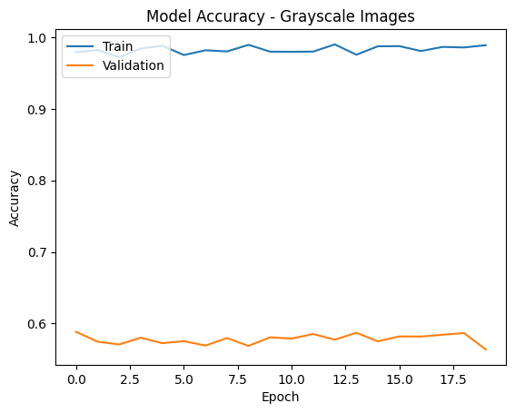

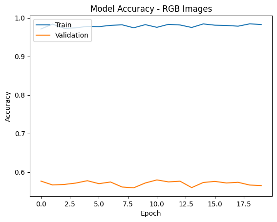

```python
# plot the accuracies of each model during training
plot_model(cnn_history_GRAY, 'GRAY')
plot_model(cnn_history_RGB, 'RGB')
```

**Observations and Insights: cnn_model_1**

- this model is severely overfit, with almost 100% accuracy on the training data, but accuracy on the validation data remaining below 60% -using rgb vs greyscale images appears to have had little impact on performance, it did not affect training times either
- the model does not appear to be learning as the validation accuracy does not improve with additional epochs
- we should decrease the number of epochs and make incremental adjustments to the model until we observe signs of learning

### **Evaluating the Model on the Test Set**

```python
#test GRAYSCALE model
print('         GRAYSCALE model:')
test_model(cnn_model_1_GRAY, 'GRAY')
print('')
print('                         # # #')
print('')
#test RGB model
print('         RGB model:')
test_model(cnn_model_1_RGB, 'RGB')
```

```
         GRAYSCALE model:
{'happy': 0, 'sad': 1, 'neutral': 2, 'surprise': 3}
              precision    recall  f1-score   support

           0       0.66      0.63      0.64        30
           1       0.62      0.52      0.56        31
           2       0.66      0.74      0.70        31
           3       0.67      0.74      0.70        19

    accuracy                           0.65       111
   macro avg       0.65      0.66      0.65       111
weighted avg       0.65      0.65      0.65       111


                         # # #

         RGB model:
{'happy': 0, 'sad': 1, 'neutral': 2, 'surprise': 3}
              precision    recall  f1-score   support

           0       0.58      0.50      0.54        30
           1       0.47      0.55      0.51        31
           2       0.41      0.39      0.40        31
           3       0.70      0.74      0.72        19

    accuracy                           0.52       111
   macro avg       0.54      0.54      0.54       111
weighted avg       0.52      0.52      0.52       111
```

**Observations:**

- the greyscale model has performed noticeably better
- with an accuracy of about 65% on the test data we can likely do better
- however, this is a decent starting point and a good proof of concept as we know our model is able to perform better than random guessing

### **Adjusting The Base Neural Network**

We will implement many different convolutional modes/layers later on, so for now let's focus on the base neural network on its own (the ANN that our CNN models will work on top of). Lets try to adjust the ANN portion of our model to find an optimal base NN to add different CNNs to. We are already overfit, so we will focus solely on trying to improve validation accuracies. We will also only test on grayscale images to save time.

```python
def cnn_model_1a():
# this part to remain the same =====================================================================
  model1 = Sequential()
  model1.add(Conv2D(24, (4, 4), padding="same", input_shape=(48, 48, 1)))
  model1.add(LeakyReLU(0.1))
  model1.add(Conv2D(48, (4, 4), padding="same"))
  model1.add(LeakyReLU(0.1))
  model1.add(MaxPooling2D((3, 3)))
  model1.add(Flatten())
# ^this part to remain the same ^ ==================================================================

  # increase number of nodes from 100 to 1000
  model1.add(Dense(1000))
  # increase number of nodes from 100 to 1000
  model1.add(Dense(1000))
  # add new layer with 500 nodes
  model1.add(Dense(500))

  # unchanged
  model1.add(Dense(4, activation='softmax'))
  # unchanged
  model1.compile(loss = 'categorical_crossentropy',
              metrics = ['accuracy'],
              optimizer=tf.keras.optimizers.Adam(learning_rate=0.001))

  return model1
```

```python
# load/compile model
cnn_model_1a = cnn_model_1a()
```

```python
# reset backend and random seed
# reset_environment()

cnn_history_1a = train_model(cnn_model_1a, 10, 'GRAY')
```

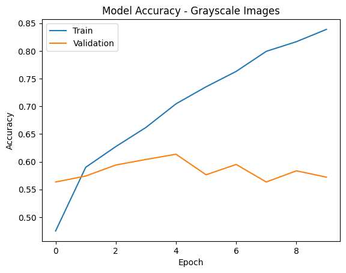

```python
# plot trainging vs validation accuracy
plot_model(cnn_history_1a, 'GRAY')
```

```python
# test the model on the test data
test_model(cnn_model_1a, 'GRAY')
```

```
{'happy': 0, 'sad': 1, 'neutral': 2, 'surprise': 3}
              precision    recall  f1-score   support

           0       0.73      0.63      0.68        30
           1       0.55      0.68      0.61        31
           2       0.63      0.61      0.62        31
           3       0.88      0.79      0.83        19

    accuracy                           0.67       111
   macro avg       0.70      0.68      0.69       111
weighted avg       0.68      0.67      0.67       111
```

**Observations:**

- the model is at least showing signs of learning the training data
- still no sign of generalized learning, as performance on the validation set does not improve with the number of epochs
- let's continue to add to our model...

```python
def cnn_model_1b():
# this part to remain the same =====================================================================
  model1 = Sequential()
  model1.add(Conv2D(24, (4, 4), padding="same", input_shape=(48, 48, 1)))
  model1.add(LeakyReLU(0.1))
  model1.add(Conv2D(48, (4, 4), padding="same"))
  model1.add(LeakyReLU(0.1))
  model1.add(MaxPooling2D((3, 3)))
  model1.add(Flatten())
# this part to remain the same =====================================================================

  # same as previous model
  model1.add(Dense(1000))
  # same as previous model
  model1.add(Dense(1000))

  # add new layer with 1000 nodes
  model1.add(Dense(1000))
  # add new layer with 1000 nodes
  model1.add(Dense(1000))
  # add new layer with 1000 nodes
  model1.add(Dense(1000))
  # add new layer with 1000 nodes
  model1.add(Dense(1000))

  # same as previous model
  model1.add(Dense(500))

  # unchanged
  model1.add(Dense(4, activation='softmax'))
  # unchanged
  model1.compile(loss = 'categorical_crossentropy',
              metrics = ['accuracy'],
              optimizer=tf.keras.optimizers.Adam(learning_rate=0.001))

  return model1
```

```python
# load/compile model
cnn_model_1b = cnn_model_1b()

# train the model, plot performance and evaluate model on test data
cnn_history_1b = train_model(cnn_model_1b, 10, 'GRAY')
```

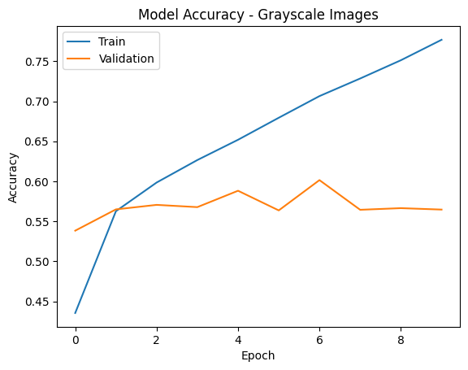

```python
# plot the accuracies of each model during training
plot_model(cnn_history_1b, 'GRAY')
```

```python
test_model(cnn_model_1b, 'GRAY')
```

```
{'happy': 0, 'sad': 1, 'neutral': 2, 'surprise': 3}
              precision    recall  f1-score   support

           0       0.73      0.53      0.62        30
           1       0.64      0.52      0.57        31
           2       0.53      0.74      0.62        31
           3       0.67      0.74      0.70        19

    accuracy                           0.62       111
   macro avg       0.64      0.63      0.63       111
weighted avg       0.64      0.62      0.62       111
```

**Observations:**

- we still do not seem to be seeing signs of generalized learning
- intestingly, the additional layers/node did not improve accuracy on the test data
- let's see if we can improve generalized learning (ie validation accuracy) with even more nodes/layers

```python
def cnn_model_1c():
# this part to remain the same =====================================================================
  model1 = Sequential()
  model1.add(Conv2D(24, (4, 4), padding="same", input_shape=(48, 48, 1)))
  model1.add(LeakyReLU(0.1))
  model1.add(Conv2D(48, (4, 4), padding="same"))
  model1.add(LeakyReLU(0.1))
  model1.add(MaxPooling2D((3, 3)))
  model1.add(Flatten())
# ^ this part to remain the same ^ =================================================================

  # increase nodes from 1000 to 2000
  model1.add(Dense(2000))
  # increase nodes from 1000 to 2000
  model1.add(Dense(2000))
  # increase nodes from 1000 to 2000
  model1.add(Dense(2000))
  # increase nodes from 1000 to 2000
  model1.add(Dense(2000))
  ## increase nodes from 1000 to 2000
  model1.add(Dense(2000))

  # same as previous model
  model1.add(Dense(1000))

  # add new layer with 1000 nodes
  model1.add(Dense(1000))

  # add new layer with 1000 nodes
  model1.add(Dense(1000))
  # add new layer with 1000 nodes
  model1.add(Dense(1000))
  # add new layer with 1000 nodes
  model1.add(Dense(1000))

  # same as previous model
  model1.add(Dense(500))

  # unchanged
  model1.add(Dense(4, activation='softmax'))
  # unchanged
  model1.compile(loss = 'categorical_crossentropy',
              metrics = ['accuracy'],
              optimizer=tf.keras.optimizers.Adam(learning_rate=0.001))

  return model1
```

```python
# load/compile model
cnn_model_1c = cnn_model_1c()

# train the model
cnn_history_1c = train_model(cnn_model_1c, 10, 'GRAY')
# train_plot_test(cnn_model_1c, 10)
```

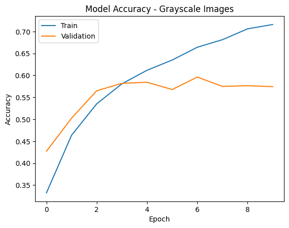

```python
plot_model(cnn_history_1c, 'GRAY')
```

```python
test_model(cnn_model_1c, 'GRAY')
```

```
{'happy': 0, 'sad': 1, 'neutral': 2, 'surprise': 3}
              precision    recall  f1-score   support

           0       0.77      0.57      0.65        30
           1       0.56      0.58      0.57        31
           2       0.69      0.71      0.70        31
           3       0.56      0.74      0.64        19

    accuracy                           0.64       111
   macro avg       0.65      0.65      0.64       111
weighted avg       0.65      0.64      0.64       111
```

```python
def cnn_model_1d():
# this part to remain the same =====================================================================
  model1 = Sequential()
  model1.add(Conv2D(24, (4, 4), padding="same", input_shape=(48, 48, 1)))
  model1.add(LeakyReLU(0.1))
  model1.add(Conv2D(48, (4, 4), padding="same"))
  model1.add(LeakyReLU(0.1))
  model1.add(MaxPooling2D((3, 3)))
  model1.add(Flatten())
# this part to remain the same =====================================================================

  # increase nodes from 2000 to 5000
  model1.add(Dense(5000))
  # increase nodes from 2000 to 5000
  model1.add(Dense(5000))
  # increase nodes from 2000 to 5000
  model1.add(Dense(5000))
  # increase nodes from 2000 to 5000
  model1.add(Dense(5000))
  ## increase nodes from 2000 to 5000
  model1.add(Dense(5000))
  # increase nodes from 1000 to 2000
  model1.add(Dense(2000))
  # increase nodes from 1000 to 2000
  model1.add(Dense(2000))
  # increase nodes from 1000 to 2000
  model1.add(Dense(2000))
  # increase nodes from 1000 to 2000
  model1.add(Dense(2000))

  # same as previous model
  model1.add(Dense(1000))

  #add drop out layer to (hopefully) help reduce overfitting
  model1.add(Dropout(.5))

  # same as previous model
  model1.add(Dense(500))
  # unchanged
  model1.add(Dense(4, activation='softmax'))
  # unchanged
  model1.compile(loss = 'categorical_crossentropy',
              metrics = ['accuracy'],
              optimizer=tf.keras.optimizers.Adam(learning_rate=0.001))

  return model1
```

```python
# load/compile model
cnn_model_1d = cnn_model_1d()

#train the model
#using a larger number of epochs as it is a larger model and validation accuracy needed more epochs to max out
cnn_history_1d = train_model(cnn_model_1d, 30, 'GRAY')
# train model, plot accuracy performance, evaluate on test data
# train_plot_test(cnn_model_1d, 30)
```

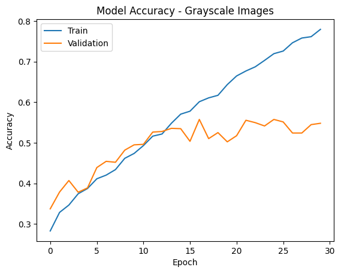

```python
#plot the model's performance
plot_model(cnn_history_1d, 'GRAY')
```

```python
test_model(cnn_model_1d, 'GRAY')
```

```
{'happy': 0, 'sad': 1, 'neutral': 2, 'surprise': 3}
              precision    recall  f1-score   support

           0       0.81      0.57      0.67        30
           1       0.62      0.58      0.60        31
           2       0.54      0.81      0.65        31
           3       0.73      0.58      0.65        19

    accuracy                           0.64       111
   macro avg       0.68      0.63      0.64       111
weighted avg       0.67      0.64      0.64       111
```

**Observations:**

- this is our largest NN and, interestingly, performance has not improved
- it seems by adding nodes/layers we are simply increasing the level of complexity to get similar results
- the current model is substantially slower to train (and requires much more memory) but shows no signs of improved performance, so a simpler model will likely be a better base model to work with
- since cnn_model_1a showed the best performance on the test data, let's go back to that model and see fi we can improve it

#### **cnn_model_1a2**

```python
def cnn_model_1a2():
# this part to remain the same =====================================================================
  model1 = Sequential()
  model1.add(Conv2D(24, (4, 4), padding="same", input_shape=(48, 48, 1)))
  model1.add(LeakyReLU(0.1))
  model1.add(Conv2D(48, (4, 4), padding="same"))
  model1.add(LeakyReLU(0.1))
  model1.add(MaxPooling2D((3, 3)))
  model1.add(Flatten())
# ^this part to remain the same ^ ==================================================================

  # change activaiton to relu
  model1.add(Dense(1000, activation = 'relu'))

  #add a dropout layer
  model1.add(Dropout(.2))

  #change activation to relu
  model1.add(Dense(1000, activation = 'relu'))

  #add a dropout layer
  model1.add(Dropout(.2))

  #change activaiton to relu
  model1.add(Dense(500, activation = 'relu'))

  #add a dropout layer
  model1.add(Dropout(.2))

  # unchanged
  model1.add(Dense(4, activation='softmax'))
  # unchanged
  model1.compile(loss = 'categorical_crossentropy',
              metrics = ['accuracy'],
              optimizer=tf.keras.optimizers.Adam(learning_rate=0.001))

  return model1
```

```python
cnn_model_1a2 = cnn_model_1a2()
```

```python
cnn_history_1a2 = train_model(cnn_model_1a2, 20, 'GRAY')
```

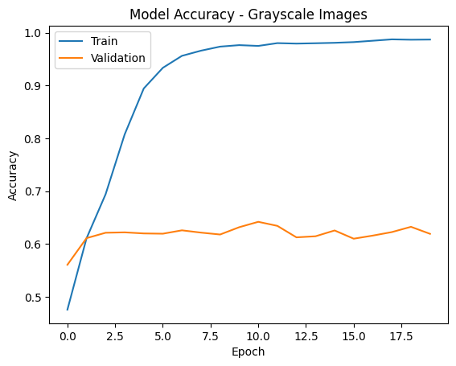

```python
plot_model(cnn_history_1a2, 'GRAY')
```

```python
test_model(cnn_model_1a2, 'GRAY')
```

```
{'happy': 0, 'sad': 1, 'neutral': 2, 'surprise': 3}
              precision    recall  f1-score   support

           0       0.70      0.70      0.70        30
           1       0.56      0.58      0.57        31
           2       0.67      0.71      0.69        31
           3       0.88      0.74      0.80        19

    accuracy                           0.68       111
   macro avg       0.70      0.68      0.69       111
weighted avg       0.68      0.68      0.68       111
```

**Observations: cnn_model_1a2**

- this model performed slightly better on the test data than cnn_model_1a
- **we will adopt this model as our base model to build CNNs ontop of**

#### **Define Base Model**

```python
# storing the base model for easy access
def get_base_model(shape_of_input):

  model1 = Sequential(name = 'BASE_MODEL')
  model1.add(Dense(1000, activation = 'relu', input_shape = shape_of_input))
  model1.add(Dropout(.2))
  model1.add(Dense(1000, activation = 'relu'))
  model1.add(Dropout(.2))
  model1.add(Dense(500, activation = 'relu'))
  model1.add(Dropout(.2))
  model1.add(Dense(4, activation='softmax'))

  return model1
```

### **Creating the second Convolutional Neural Network**

```python
def cnn_model_2(shape_of_input):
  model = Sequential()
  model.add(Conv2D(24, (4, 4), padding="same", input_shape = shape_of_input))
  model.add(LeakyReLU(0.1))
  model.add(Conv2D(48, (4, 4), padding="same"))
  model.add(LeakyReLU(0.1))
  model.add(MaxPooling2D((3, 3)))

  model.add(Conv2D(24, (4, 4), padding="same"))
  model.add(LeakyReLU(0.1))
  model.add(Conv2D(48, (4, 4), padding="same"))
  model.add(LeakyReLU(0.1))
  model.add(MaxPooling2D((3, 3)))

  model.add(Flatten())

  ### BASE MODEL ###
  model.add(get_base_model((None, 1200)))


  # Compile model
  model.compile(loss = 'categorical_crossentropy',
              metrics = ['accuracy'],
              optimizer=tf.keras.optimizers.Adam(learning_rate=0.001))

  return model
```

### **Compiling and Training the Model**

```python
# loading/compiling models
cnn_model_2_G = cnn_model_2((48,48,1))
cnn_model_2_RGB = cnn_model_2((48,48,3))

# Generating the summary of the grayscale model
cnn_model_2_G.summary()
```

```
Model: "sequential"
_________________________________________________________________
 Layer (type)                Output Shape              Param #
=================================================================
 conv2d (Conv2D)             (None, 48, 48, 24)        408

 leaky_re_lu (LeakyReLU)     (None, 48, 48, 24)        0

 conv2d_1 (Conv2D)           (None, 48, 48, 48)        18480

 leaky_re_lu_1 (LeakyReLU)   (None, 48, 48, 48)        0

 max_pooling2d (MaxPooling2D  (None, 16, 16, 48)       0
 )

 conv2d_2 (Conv2D)           (None, 16, 16, 24)        18456

 leaky_re_lu_2 (LeakyReLU)   (None, 16, 16, 24)        0

 conv2d_3 (Conv2D)           (None, 16, 16, 48)        18480

 leaky_re_lu_3 (LeakyReLU)   (None, 16, 16, 48)        0

 max_pooling2d_1 (MaxPooling  (None, 5, 5, 48)         0
 2D)

 flatten (Flatten)           (None, 1200)              0

 BASE_MODEL (Sequential)     (None, None, 4)           2704504

=================================================================
Total params: 2,760,328
Trainable params: 2,760,328
Non-trainable params: 0
_________________________________________________________________
```

```python
# train the models
cnn_history_2_G = train_model(cnn_model_2_G, 20, 'GRAY')
cnn_history_2_RGB = train_model(cnn_model_2_RGB, 20, 'RGB')
```

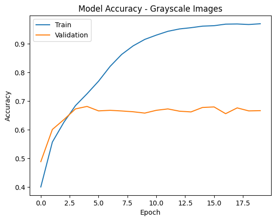

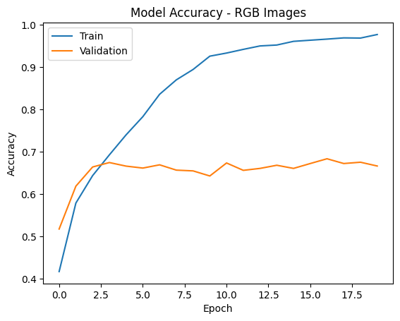

```python
#plot model performance
plot_model(cnn_history_2_G, 'GRAY')
plot_model(cnn_history_2_RGB, 'RGB')
```

```python
# test the models
#test GRAYSCALE model
print('        ** GRAYSCALE model **')
test_model(cnn_model_2_G, 'GRAY')
print('')
print('                         # # #')
print('')
#test RGB model
print('        ** RGB model **')
test_model(cnn_model_2_RGB, 'RGB')
```

[output not shown]

**Observations and Insights: cnn_model_2**

- while the model is still overfit to the training data, this is the grayscale model is the best model we have seen yet!
- let's add to (and subtract from) our convolutional network to see how it impacts performnce

### **Adjusting the Convolutional Neural Network**

```python
def cnn_model_2a(shape_of_input):
  # Intializing a sequential model
  model_2 = Sequential()

  # Adding first conv layer with 16 filters and kernel size 3x3 , padding 'same,' provides the output size same as the input size
  model_2.add(Conv2D(3, (3, 3), padding="same", input_shape=shape_of_input))
  # Adding LeakyRelu activation function with a slope of 0.1
  model_2.add(LeakyReLU(0.1))
  # Adding second conv layer with 32 filters and kernel size 3x3 , padding 'same'
  model_2.add(Conv2D(48, (3, 3), padding="same"))
  # Adding another LeakyRelu activation function with a slope of 0.1
  model_2.add(LeakyReLU(0.1))
  # Adding max pooling layer
  model_2.add(MaxPooling2D(pool_size=(4, 4)))
  # Add batch normalization layer
  model_2.add(BatchNormalization())
  # Adding third conv layer with 32 filters and kernel size 3x3 , padding 'same'
  model_2.add(Conv2D(48, (4, 4), padding="same"))
  # Adding another LeakyRelu activation function with a slope of 0.1
  model_2.add(LeakyReLU(0.1))
  # Adding fourth conv layer with 64 filters and kernel size 3x3 , padding 'same'
  model_2.add(Conv2D(96, (5, 5), padding="same"))
  # Adding another LeakyRelu activation function with a slope of 0.1
  model_2.add(Dropout(.4))
  # Adding max pooling layer
  model_2.add(MaxPooling2D(pool_size=(4, 4)))
  # Add batch normalization layer
  model_2.add(BatchNormalization())
  # flattening the output of the conv layer after max pooling to make it ready for creating dense connections
  model_2.add(Flatten())

  ### BASE MODEL ###
  model_2.add(get_base_model((None, 864)))

  # Compile model
  model_2.compile(loss = 'categorical_crossentropy',
              metrics = ['accuracy'],
              optimizer=tf.keras.optimizers.Adam(learning_rate=0.00001))

  return model_2
```

```python
# loading/compiling both models
cnn_model_2a_RGB = cnn_model_2a((48,48,3))
cnn_model_2a_GRAY = cnn_model_2a((48,48,1))
```

```python
# train the models
cnn_history_2a_G = train_model(cnn_model_2a_GRAY, 20, 'GRAY')
cnn_history_2a_RGB = train_model(cnn_model_2a_RGB, 20, 'RGB')
```

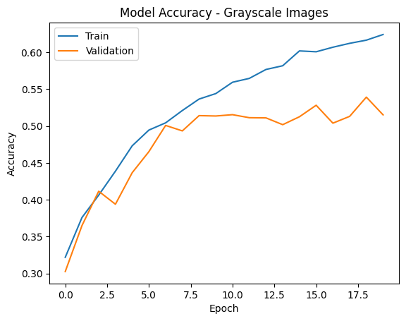

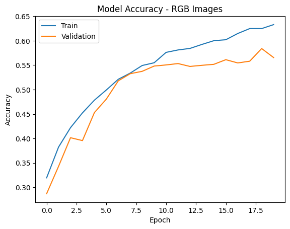

```python
# plot model performance
plot_model(cnn_history_2a_G, 'GRAY')
plot_model(cnn_history_2a_RGB, 'RGB')
```

```python
# test the models
#test GRAYSCALE model
print('       ** GRAYSCALE model **')
test_model(cnn_model_2a_GRAY, 'GRAY')
print('')
print('                         # # #')
print('')
#test RGB model
print('       ** RGB model **')
test_model(cnn_model_2a_RGB, 'RGB')
```

```
       ** GRAYSCALE model **
{'happy': 0, 'sad': 1, 'neutral': 2, 'surprise': 3}
              precision    recall  f1-score   support

           0       0.79      0.50      0.61        30
           1       0.41      0.90      0.56        31
           2       0.73      0.35      0.48        31
           3       0.88      0.37      0.52        19

    accuracy                           0.55       111
   macro avg       0.70      0.53      0.54       111
weighted avg       0.68      0.55      0.54       111


                         # # #

       ** RGB model **
{'happy': 0, 'sad': 1, 'neutral': 2, 'surprise': 3}
              precision    recall  f1-score   support

           0       0.71      0.57      0.63        30
           1       0.38      0.74      0.51        31
           2       0.56      0.29      0.38        31
           3       0.91      0.53      0.67        19

    accuracy                           0.53       111
   macro avg       0.64      0.53      0.55       111
weighted avg       0.61      0.53      0.53       111
```

**Observations:**

- cnn_model_2a performed worse than the previous model
- let's build on the CNN to see if it improves performance

```python
def cnn_model_2b(shape_of_input):
  # Intializing a sequential model
  model_2 = Sequential()

  # Adding first conv layer with 16 filters and kernel size 3x3 , padding 'same,' provides the output size same as the input size
  model_2.add(Conv2D(48, (3, 3), padding="same", input_shape=shape_of_input))
  # Adding LeakyRelu activation function with a slope of 0.1
  model_2.add(LeakyReLU(0.1))
  # Adding second conv layer with 32 filters and kernel size 3x3 , padding 'same'
  model_2.add(Conv2D(48, (3, 3), padding="same"))
  # Adding another LeakyRelu activation function with a slope of 0.1
  model_2.add(LeakyReLU(0.1))
  # Adding max pooling layer
  model_2.add(Conv2D(48, (3, 3), padding="same"))
  # Adding another LeakyRelu activation function with a slope of 0.1
  model_2.add(LeakyReLU(0.1))
  # Adding max pooling layer
  model_2.add(Conv2D(48, (3, 3), padding="same"))
  # Adding another LeakyRelu activation function with a slope of 0.1
  model_2.add(LeakyReLU(0.1))
  # Adding max pooling layer
  model_2.add(MaxPooling2D(pool_size=(4, 4)))
  # Add batch normalization layer
  model_2.add(BatchNormalization())
  # Adding third conv layer with 32 filters and kernel size 3x3 , padding 'same'
  model_2.add(Conv2D(48, (4, 4), padding="same"))
  # Adding another LeakyRelu activation function with a slope of 0.1
  model_2.add(LeakyReLU(0.1))
  # Adding fourth conv layer with 64 filters and kernel size 3x3 , padding 'same'
  model_2.add(Conv2D(96, (5, 5), padding="same"))
  # Adding another LeakyRelu activation function with a slope of 0.1
  model_2.add(Conv2D(96, (5, 5), padding="same"))
  # Adding another LeakyRelu activation function with a slope of 0.1
  model_2.add(Conv2D(96, (5, 5), padding="same"))
  # Adding another LeakyRelu activation function with a slope of 0.1
  model_2.add(Dropout(.4))
  # Adding max pooling layer
  # Adding third conv layer with 32 filters and kernel size 3x3 , padding 'same'
  model_2.add(Conv2D(48, (4, 4), padding="same"))
  # Adding another LeakyRelu activation function with a slope of 0.1
  model_2.add(LeakyReLU(0.1))
  # Adding fourth conv layer with 64 filters and kernel size 3x3 , padding 'same'
  model_2.add(Conv2D(96, (5, 5), padding="same"))
  # Adding another LeakyRelu activation function with a slope of 0.1
  model_2.add(Conv2D(48, (4, 4), padding="same"))
  # Adding another LeakyRelu activation function with a slope of 0.1
  model_2.add(LeakyReLU(0.1))
  # Adding fourth conv layer with 64 filters and kernel size 3x3 , padding 'same'
  model_2.add(Conv2D(48, (4, 4), padding="same"))
  # Adding another LeakyRelu activation function with a slope of 0.1
  model_2.add(LeakyReLU(0.1))
  # Adding fourth conv layer with 64 filters and kernel size 3x3 , padding 'same'
  model_2.add(Dropout(.4))
  # Adding max pooling layer
  model_2.add(MaxPooling2D(pool_size=(4, 4)))
  # Add batch normalization layer
  model_2.add(BatchNormalization())

  # flattening the output of the conv layer after max pooling to make it ready for creating dense connections
  model_2.add(Flatten())

  ### BASE MODEL ###
  model_2.add(get_base_model((None, 432)))

  # Compile model
  model_2.compile(loss = 'categorical_crossentropy',
              metrics = ['accuracy'],
              optimizer=tf.keras.optimizers.Adam(learning_rate=0.00001))

  return model_2
```

```python
# loading/compiling the models
cnn_model_2b_G = cnn_model_2b((48,48,1))
cnn_model_2b_RGB = cnn_model_2b((48,48,3))
```

```python
#train the models
cnn_history_2b_G = train_model(cnn_model_2b_G, 20, 'GRAY')
cnn_history_2b_RGB = train_model(cnn_model_2b_RGB, 20, 'RGB')
```

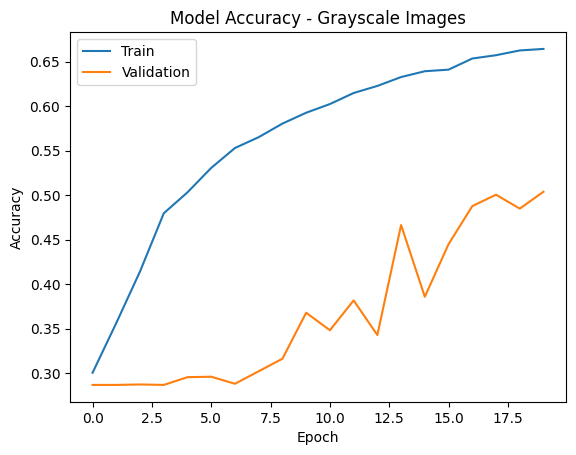

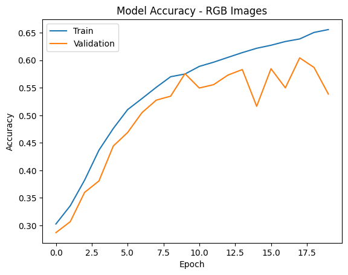

```python
#plot model performance
plot_model(cnn_history_2b_G, 'GRAY')
plot_model(cnn_history_2b_RGB, 'RGB')
```

```python
#test GRAYSCALE model
print('       ** GRAYSCALE model **')
test_model(cnn_model_2b_G, 'GRAY')
print('')
print('                         # # #')
print('')
#test RGB model
print('       ** RGB model **')
test_model(cnn_model_2b_RGB, 'RGB')
```

```
       ** GRAYSCALE model **
{'happy': 0, 'sad': 1, 'neutral': 2, 'surprise': 3}
              precision    recall  f1-score   support

           0       0.38      0.83      0.53        30
           1       0.34      0.32      0.33        31
           2       0.64      0.23      0.33        31
           3       1.00      0.32      0.48        19

    accuracy                           0.43       111
   macro avg       0.59      0.42      0.42       111
weighted avg       0.55      0.43      0.41       111


                         # # #

       ** RGB model **
{'happy': 0, 'sad': 1, 'neutral': 2, 'surprise': 3}
              precision    recall  f1-score   support

           0       0.85      0.57      0.68        30
           1       0.43      0.90      0.58        31
           2       0.65      0.42      0.51        31
           3       1.00      0.32      0.48        19

    accuracy                           0.58       111
   macro avg       0.73      0.55      0.56       111
weighted avg       0.70      0.58      0.57       111
```

**Observations:**

- these results are comparable but not as good as the results from cnn_model_2_G
- this indicates that added complexity in the CNN does not necessarily lead to better results

## **Think About It:**

- Did the models have a satisfactory performance? If not, then what are the possible reasons?
- Which Color mode showed better overall performance? What are the possible reasons? Do you think having 'rgb' color mode is needed because the images are already black and white?

**Responses:**

## **Transfer Learning Architectures**

In this section, we will create several Transfer Learning architectures. For the pre-trained models, we will select three popular architectures namely, VGG16, ResNet v2, and Efficient Net. The difference between these architectures and the previous architectures is that these will require 3 input channels while the earlier ones worked on 'grayscale' images. Therefore, we need to create new DataLoaders.

### **Creating our Data Loaders for Transfer Learning Architectures**

In this section, we are creating data loaders that we will use as inputs to our Neural Network. We will have to go with color_mode = 'rgb' as this is the required format for the transfer learning architectures.

```python
# nothing needs to be done here
# Because of the way we created our previous loaders we can simply utilize our RGB datasets
```

## **VGG16 Model**

### **Importing the VGG16 Architecture**

```python
# import the model
imported_model_VGG16 = VGG16(weights='imagenet',include_top = False, input_shape = (48,48,3))
# summary of the model
imported_model_VGG16.summary()
```

```
Model: "vgg16"
_________________________________________________________________
 Layer (type)                Output Shape              Param #
=================================================================
 input_1 (InputLayer)        [(None, 48, 48, 3)]       0

 block1_conv1 (Conv2D)       (None, 48, 48, 64)        1792

 block1_conv2 (Conv2D)       (None, 48, 48, 64)        36928

 block1_pool (MaxPooling2D)  (None, 24, 24, 64)        0

 block2_conv1 (Conv2D)       (None, 24, 24, 128)       73856

 block2_conv2 (Conv2D)       (None, 24, 24, 128)       147584

 block2_pool (MaxPooling2D)  (None, 12, 12, 128)       0

 block3_conv1 (Conv2D)       (None, 12, 12, 256)       295168

 block3_conv2 (Conv2D)       (None, 12, 12, 256)       590080

 block3_conv3 (Conv2D)       (None, 12, 12, 256)       590080

 block3_pool (MaxPooling2D)  (None, 6, 6, 256)         0

 block4_conv1 (Conv2D)       (None, 6, 6, 512)         1180160

 block4_conv2 (Conv2D)       (None, 6, 6, 512)         2359808

 block4_conv3 (Conv2D)       (None, 6, 6, 512)         2359808

 block4_pool (MaxPooling2D)  (None, 3, 3, 512)         0

 block5_conv1 (Conv2D)       (None, 3, 3, 512)         2359808

 block5_conv2 (Conv2D)       (None, 3, 3, 512)         2359808

 block5_conv3 (Conv2D)       (None, 3, 3, 512)         2359808

 block5_pool (MaxPooling2D)  (None, 1, 1, 512)         0

=================================================================
Total params: 14,714,688
Trainable params: 14,714,688
Non-trainable params: 0
_________________________________________________________________
```

### **Model Building**

- Import VGG16 upto the layer of your choice and add Fully Connected layers on top of it.

```python
# Getting only the conv layers for transfer learning.
transfer_layer = imported_model_VGG16.get_layer('block5_pool')
vgg_conv_layers = Model(inputs=imported_model_VGG16.input, outputs=transfer_layer.output)

# make sure pre-trained layers will not be trained
vgg_conv_layers.trainable=False
```

```python
def cnn_model_VGG():
  # Intializing a sequential model
  model = Sequential()

  model.add(vgg_conv_layers)
  model.add(Flatten())

  ### BASE MODEL ###
  model.add(get_base_model((None, 512)))

  # Compile model
  model.compile(loss = 'categorical_crossentropy',
              metrics = ['accuracy'],
              optimizer=tf.keras.optimizers.Adam(learning_rate=0.001))

  return model
```

### **Compiling and Training & Evaluating the VGG16 Model**

```python
# load/compile model
cnn_model_VGG = cnn_model_VGG()
# print summary of the model
cnn_model_VGG.summary()
```

```
Model: "sequential_1"
_________________________________________________________________
 Layer (type)                Output Shape              Param #
=================================================================
 model_1 (Functional)        (None, 1, 1, 512)         14714688

 flatten_1 (Flatten)         (None, 512)               0

 BASE_MODEL (Sequential)     (None, None, 4)           2016504

=================================================================
Total params: 16,731,192
Trainable params: 2,016,504
Non-trainable params: 14,714,688
_________________________________________________________________
```

```python
#train the model
vgg_history = train_model(cnn_model_VGG, 50, 'RGB')

# train the VGG model, plot its accuracies, test the model
# train_plot_test_RGB(cnn_model_VGG, 90)
```

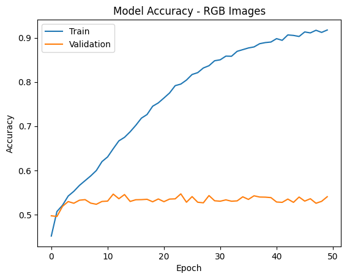

```python
#plot performance
plot_model(vgg_history, 'RGB')
```

```python
# test the model
test_model(cnn_model_VGG, 'RGB')
```

```
{'happy': 0, 'sad': 1, 'neutral': 2, 'surprise': 3}
              precision    recall  f1-score   support

           0       0.67      0.53      0.59        30
           1       0.56      0.48      0.52        31
           2       0.50      0.65      0.56        31
           3       0.65      0.68      0.67        19

    accuracy                           0.58       111
   macro avg       0.59      0.59      0.58       111
weighted avg       0.59      0.58      0.58       111
```

**Think About It:**

- What do you infer from the general trend in the training performance?
- Is the training accuracy consistently improving?
- Is the validation accuracy also improving similarly?

**Responses:**

- this model is not especially good at identify facial expreions, but not significantly wore than other models we have tests
- training accuracy improves over the first 50 epochs
- validation accuracy does not seem to improve beyond 10 epochs, suggesting that the model is simply learning to overfit the training data

**Observations and Insights: cnn_model_VGG**

- the model is not substantially better than other models we have tested, and it is meaningfully worse than the current best model, cnn_model_2_G
- let's try utiliing other pre-trained models and see how they perform

**Note: You can even go back and build your own architecture on top of the VGG16 Transfer layer and see if you can improve the performance**

## **ResNet V2 Model**

### **Model Building**

- Import Resnet v2 upto the layer of your choice and add Fully Connected layers on top of it.

```python
imported_model_Resnet = ap.ResNet101(include_top = False, weights = "imagenet", input_shape=(48,48,3))
imported_model_Resnet.summary()
```

```
Downloading data from https://storage.googleapis.com/tensorflow/keras-applications/resnet/resnet101_weights_tf_dim_ordering_tf_kernels_notop.h5
Model: "resnet101"
__________________________________________________________________________________________________
 Layer (type)                   Output Shape         Param #     Connected to
==================================================================================================
 input_1 (InputLayer)           [(None, 48, 48, 3)]  0           []

 conv1_pad (ZeroPadding2D)      (None, 54, 54, 3)    0           ['input_1[0][0]']

 conv1_conv (Conv2D)            (None, 24, 24, 64)   9472        ['conv1_pad[0][0]']

 conv1_bn (BatchNormalization)  (None, 24, 24, 64)   256         ['conv1_conv[0][0]']

 conv1_relu (Activation)        (None, 24, 24, 64)   0           ['conv1_bn[0][0]']

 pool1_pad (ZeroPadding2D)      (None, 26, 26, 64)   0           ['conv1_relu[0][0]']

 pool1_pool (MaxPooling2D)      (None, 12, 12, 64)   0           ['pool1_pad[0][0]']

 conv2_block1_1_conv (Conv2D)   (None, 12, 12, 64)   4160        ['pool1_pool[0][0]']

 conv2_block1_1_bn (BatchNormal  (None, 12, 12, 64)  256         ['conv2_block1_1_conv[0][0]']
 ization)

 conv2_block1_1_relu (Activatio  (None, 12, 12, 64)  0           ['conv2_block1_1_bn[0][0]']
 n)

 conv2_block1_2_conv (Conv2D)   (None, 12, 12, 64)   36928       ['conv2_block1_1_relu[0][0]']

 conv2_block1_2_bn (BatchNormal  (None, 12, 12, 64)  256         ['conv2_block1_2_conv[0][0]']
 ization)

 conv2_block1_2_relu (Activatio  (None, 12, 12, 64)  0           ['conv2_block1_2_bn[0][0]']
 n)

 conv2_block1_0_conv (Conv2D)   (None, 12, 12, 256)  16640       ['pool1_pool[0][0]']

 conv2_block1_3_conv (Conv2D)   (None, 12, 12, 256)  16640       ['conv2_block1_2_relu[0][0]']

 conv2_block1_0_bn (BatchNormal  (None, 12, 12, 256)  1024       ['conv2_block1_0_conv[0][0]']
```

[output cut: 847 more lines]

```
 conv5_block3_3_conv (Conv2D)   (None, 2, 2, 2048)   1050624     ['conv5_block3_2_relu[0][0]']

 conv5_block3_3_bn (BatchNormal  (None, 2, 2, 2048)  8192        ['conv5_block3_3_conv[0][0]']
 ization)

 conv5_block3_add (Add)         (None, 2, 2, 2048)   0           ['conv5_block2_out[0][0]',
                                                                  'conv5_block3_3_bn[0][0]']

 conv5_block3_out (Activation)  (None, 2, 2, 2048)   0           ['conv5_block3_add[0][0]']

==================================================================================================
Total params: 42,658,176
Trainable params: 42,552,832
Non-trainable params: 105,344
__________________________________________________________________________________________________
```

```python
# Getting only the conv layers for transfer learning.
transfer_layer = imported_model_Resnet.get_layer('conv5_block3_out')
resnet_conv_layers = Model(inputs=imported_model_Resnet.input, outputs=transfer_layer.output)

# make sure pre-trained layers will not be trained
resnet_conv_layers.trainable=False
```

```python
def cnn_model_Resnet():
  # Intializing a sequential model
  model = Sequential()

  model.add(resnet_conv_layers)

  model.add(Flatten())

  ### BASE MODEL ###
  model.add(get_base_model((None, 8192)))

  # Compile model
  model.compile(loss = 'categorical_crossentropy',
              metrics = ['accuracy'],
              optimizer=tf.keras.optimizers.Adam(learning_rate=0.001))

  return model
```

### **Compiling and Training the Model**

```python
# load/compile model
cnn_model_Resnet = cnn_model_Resnet()

# train the model
cnn_history_Resnet = train_model(cnn_model_Resnet, 50, 'RGB')
```

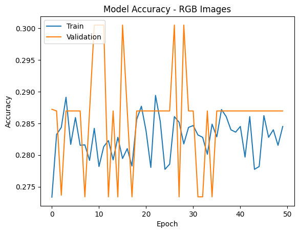

```python
plot_model(cnn_history_Resnet, 'RGB')
```

### **Evaluating the ResNet Model**

```python
test_model(cnn_model_Resnet, 'RGB')
```

```
{'happy': 0, 'sad': 1, 'neutral': 2, 'surprise': 3}
              precision    recall  f1-score   support

           0       0.27      1.00      0.43        30
           1       0.00      0.00      0.00        31
           2       0.00      0.00      0.00        31
           3       0.00      0.00      0.00        19

    accuracy                           0.27       111
   macro avg       0.07      0.25      0.11       111
weighted avg       0.07      0.27      0.12       111
```

**Observations and Insights: cnn_model_Resnet**

- This model has performed very poorly
- accuracy on th training data never exceeds .3
- accuracy on the validation data oscilates between about .3 and .275
- the "learnings" from the model's previous training does not carry over to our use case

**Note: You can even go back and build your own architecture on top of the ResNet Transfer layer and see if you can improve the performance.**

## **EfficientNet Model**

```python
# import the EfficientNet model
imported_model_EfficientNet = ap.EfficientNetV2B2(include_top=False,weights="imagenet", input_shape= (48, 48, 3))

# print summary of the model
imported_model_EfficientNet.summary()
```

```
Downloading data from https://storage.googleapis.com/tensorflow/keras-applications/efficientnet_v2/efficientnetv2-b2_notop.h5
Model: "efficientnetv2-b2"
__________________________________________________________________________________________________
 Layer (type)                   Output Shape         Param #     Connected to
==================================================================================================
 input_1 (InputLayer)           [(None, 48, 48, 3)]  0           []

 rescaling (Rescaling)          (None, 48, 48, 3)    0           ['input_1[0][0]']

 normalization (Normalization)  (None, 48, 48, 3)    0           ['rescaling[0][0]']

 stem_conv (Conv2D)             (None, 24, 24, 32)   864         ['normalization[0][0]']

 stem_bn (BatchNormalization)   (None, 24, 24, 32)   128         ['stem_conv[0][0]']

 stem_activation (Activation)   (None, 24, 24, 32)   0           ['stem_bn[0][0]']

 block1a_project_conv (Conv2D)  (None, 24, 24, 16)   4608        ['stem_activation[0][0]']

 block1a_project_bn (BatchNorma  (None, 24, 24, 16)  64          ['block1a_project_conv[0][0]']
 lization)

 block1a_project_activation (Ac  (None, 24, 24, 16)  0           ['block1a_project_bn[0][0]']
 tivation)

 block1b_project_conv (Conv2D)  (None, 24, 24, 16)   2304        ['block1a_project_activation[0][0
                                                                 ]']

 block1b_project_bn (BatchNorma  (None, 24, 24, 16)  64          ['block1b_project_conv[0][0]']
 lization)

 block1b_project_activation (Ac  (None, 24, 24, 16)  0           ['block1b_project_bn[0][0]']
 tivation)

 block1b_drop (Dropout)         (None, 24, 24, 16)   0           ['block1b_project_activation[0][0
                                                                 ]']

 block1b_add (Add)              (None, 24, 24, 16)   0           ['block1b_drop[0][0]',
                                                                  'block1a_project_activation[0][0
                                                                 ]']
```

[output cut: 866 more lines]

```

 block6j_add (Add)              (None, 2, 2, 208)    0           ['block6j_drop[0][0]',
                                                                  'block6i_add[0][0]']

 top_conv (Conv2D)              (None, 2, 2, 1408)   292864      ['block6j_add[0][0]']

 top_bn (BatchNormalization)    (None, 2, 2, 1408)   5632        ['top_conv[0][0]']

 top_activation (Activation)    (None, 2, 2, 1408)   0           ['top_bn[0][0]']

==================================================================================================
Total params: 8,769,374
Trainable params: 8,687,086
Non-trainable params: 82,288
__________________________________________________________________________________________________
```

### **Model Building**

- Import EfficientNet upto the layer of your choice and add Fully Connected layers on top of it.

```python
# Getting only the conv layers for transfer learning.
transfer_layer = imported_model_EfficientNet.get_layer('top_activation')
efficientNet_conv_layers = Model(inputs=imported_model_EfficientNet.input, outputs=transfer_layer.output)

# make sure pre-trained layers will not be trained
efficientNet_conv_layers.trainable=False
```

```python
def cnn_model_EffNet():
  # Intializing a sequential model
  model = Sequential()

  model.add(efficientNet_conv_layers)

  model.add(Flatten())

  ### BASE MODEL ###
  model.add(get_base_model((None, 5632)))

  # Compile model
  model.compile(loss = 'categorical_crossentropy',
              metrics = ['accuracy'],
              optimizer=tf.keras.optimizers.Adam(learning_rate=0.001))

  return model
```

### **Compiling and Training the Model**

```python
# load/compile model
cnn_model_EffNet = cnn_model_EffNet()

# train the model
cnn_hisory_EffNet = train_model(cnn_model_EffNet, 50, 'RGB')
```

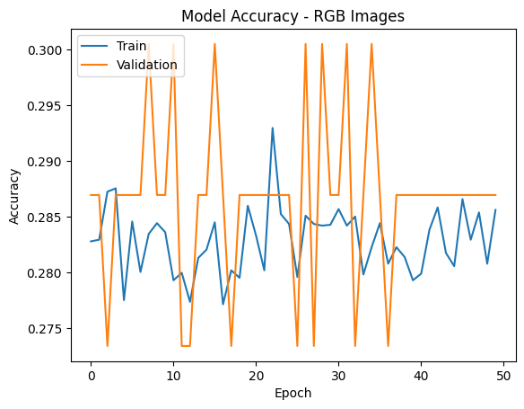

```python
#plot model performance
plot_model(cnn_hisory_EffNet, 'RGB')
```

### **Evaluating the EfficientNet Model**

```python
# test model
test_model(cnn_model_EffNet, 'RGB')
```

```
{'happy': 0, 'sad': 1, 'neutral': 2, 'surprise': 3}
              precision    recall  f1-score   support

           0       0.27      1.00      0.43        30
           1       0.00      0.00      0.00        31
           2       0.00      0.00      0.00        31
           3       0.00      0.00      0.00        19

    accuracy                           0.27       111
   macro avg       0.07      0.25      0.11       111
weighted avg       0.07      0.27      0.12       111
```

**Observations and Insights: cnn_model_EffNet**

- performance looks very similar to the Resnet model's performance
- training accuracy remains below .3
- avlidation accuracy oscillates between about .3 and .275
- again, the "learnings" or the model's previous training do not carry over to our use case

**Note: You can even go back and build your own architecture on top of the VGG16 Transfer layer and see if you can improve the performance.**

**Think About It:**

- What is your overall performance of these Transfer Learning Architectures? Can we draw a comparison of these models' performances. Are we satisfied with the accuracies that we have received?
- Do you think our issue lies with 'rgb' color_mode?

**Responses:**

- in general Transfer learning architectures did not perform well
- it seems that the models are trained for specific tasks and are not equipped to identify facial expressions
- it seems doubtful to me that the problem lies with the RGB color mode. If this were the case our own RGB models woud likely have performed substantially worse

Now that we have tried multiple pre-trained models, let's build a complex CNN architecture and see if we can get better performance.

## **Building a Complex Neural Network Architecture**

In this section, we will build a more complex Convolutional Neural Network Model that has close to as many parameters as we had in our Transfer Learning Models. However, we will have only 1 input channel for our input images.

### **Creating our Data Loaders**

In this section, we are creating data loaders which we will use as inputs to the more Complicated Convolutional Neural Network. We will go ahead with color_mode = 'grayscale'.

```python
# the needed data loaders have already been created
```

### **Model Building**

- Try building a layer with 5 Convolutional Blocks and see if performance increases.

```python
def cnn_model_3():
  model = Sequential()

  model.add(Conv2D(64, (2, 2), padding="same", input_shape = (48,48,1), activation = 'relu'))
  model.add(BatchNormalization())
  model.add(LeakyReLU(0.1))
  model.add(MaxPooling2D(pool_size=(2, 2)))
  model.add(Dropout(.2))

  model.add(Conv2D(128, (2, 2), padding="same", activation = 'relu'))
  model.add(BatchNormalization())
  model.add(LeakyReLU(0.1))
  model.add(MaxPooling2D(pool_size=(2, 2)))
  model.add(Dropout(.2))

  model.add(Conv2D(512, (2, 2), padding="same", activation = 'relu'))
  model.add(BatchNormalization())
  model.add(LeakyReLU(0.1))
  model.add(MaxPooling2D(pool_size=(2, 2)))
  model.add(Dropout(.2))

  model.add(Conv2D(512, (2, 2), padding="same", activation = 'relu'))
  model.add(BatchNormalization())
  model.add(LeakyReLU(0.1))
  model.add(MaxPooling2D(pool_size=(2, 2)))
  model.add(Dropout(.2))

  model.add(Conv2D(128, (2, 2), padding="same", activation = 'relu'))
  model.add(BatchNormalization())
  model.add(LeakyReLU(0.1))
  model.add(MaxPooling2D(pool_size=(2, 2)))
  model.add(Dropout(.2))

  model.add(Flatten())

  ### BASE MODEL ###
  model.add(get_base_model((None, 128)))


  # Compile model
  model.compile(loss = 'categorical_crossentropy',
              metrics = ['accuracy'],
              optimizer=tf.keras.optimizers.Adam(learning_rate=0.001))

  return model
```

### **Compiling and Training the Model**

```python
# load/compile the model
cnn_model_3 = cnn_model_3()

# train the model
cnn_history_3 = train_model(cnn_model_3, 40, 'GRAY')
```

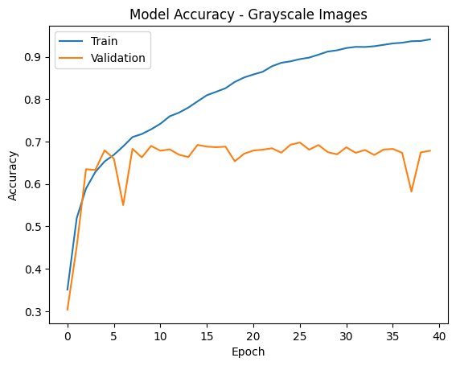

```python
plot_model(cnn_history_3, 'GRAY')
```

### **Evaluating the Model on Test Set**

```python
test_model(cnn_model_3, 'GRAY')
```

```
{'happy': 0, 'sad': 1, 'neutral': 2, 'surprise': 3}
              precision    recall  f1-score   support

           0       0.74      0.77      0.75        30
           1       0.58      0.58      0.58        31
           2       0.62      0.65      0.63        31
           3       0.88      0.79      0.83        19

    accuracy                           0.68       111
   macro avg       0.71      0.70      0.70       111
weighted avg       0.69      0.68      0.69       111
```

**Observations and Insights: cnn_model_3**

- this is a good model, but not quite as good as cnn_model_2_G
- let's change the base model and see if it improves performance

### **Adjusting the Model**

```python
def cnn_model_3a():
  model = Sequential()

  model.add(Conv2D(64, (2, 2), padding="same", input_shape = (48,48,1), activation = 'relu'))
  model.add(BatchNormalization())
  model.add(LeakyReLU(0.1))
  model.add(MaxPooling2D(pool_size=(2, 2)))
  model.add(Dropout(.2))

  model.add(Conv2D(128, (2, 2), padding="same", activation = 'relu'))
  model.add(BatchNormalization())
  model.add(LeakyReLU(0.1))
  model.add(MaxPooling2D(pool_size=(2, 2)))
  model.add(Dropout(.2))

  model.add(Conv2D(512, (2, 2), padding="same", activation = 'relu'))
  model.add(BatchNormalization())
  model.add(LeakyReLU(0.1))
  model.add(MaxPooling2D(pool_size=(2, 2)))
  model.add(Dropout(.2))

  model.add(Conv2D(512, (2, 2), padding="same", activation = 'relu'))
  model.add(BatchNormalization())
  model.add(LeakyReLU(0.1))
  model.add(MaxPooling2D(pool_size=(2, 2)))
  model.add(Dropout(.2))

  model.add(Conv2D(128, (2, 2), padding="same", activation = 'relu'))
  model.add(BatchNormalization())
  model.add(LeakyReLU(0.1))
  model.add(MaxPooling2D(pool_size=(2, 2)))
  model.add(Dropout(.2))

  model.add(Flatten())

  model.add(Dense(256, activation = 'relu'))
  model.add(BatchNormalization())
  model.add(LeakyReLU(0.1))
  model.add(Dropout(.2))

  model.add(Dense(512, activation = 'relu'))
  model.add(BatchNormalization())
  model.add(LeakyReLU(0.1))
  model.add(Dropout(.2))

  model.add(Dense(4, activation='softmax'))


  # Compile model
  model.compile(loss = 'categorical_crossentropy',
              metrics = ['accuracy'],
              optimizer=tf.keras.optimizers.Adam(learning_rate=0.001))

  return model
```

```python
# load/compile model
cnn_model_3a = cnn_model_3a()

#train model
cnn_history_3a = train_model(cnn_model_3a, 30, "GRAY")
```

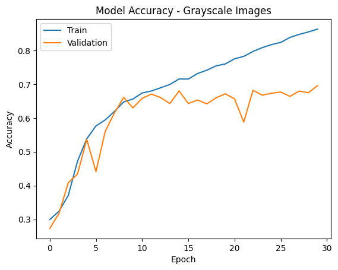

```python
#plot performance
plot_model(cnn_history_3a, 'GRAY')
```

```python
#test model
test_model(cnn_model_3a, 'GRAY')
```

```
{'happy': 0, 'sad': 1, 'neutral': 2, 'surprise': 3}
              precision    recall  f1-score   support

           0       0.75      0.80      0.77        30
           1       0.69      0.65      0.67        31
           2       0.62      0.65      0.63        31
           3       0.78      0.74      0.76        19

    accuracy                           0.70       111
   macro avg       0.71      0.71      0.71       111
weighted avg       0.70      0.70      0.70       111
```

**Observations: cnn_model_3a**

- this model's performance is comparable with cnn_model_2_G
- let's add further to the base model and see if we can get even better accuracy

#### **cnn_model_3b**

```python
def cnn_model_3b():
  model = Sequential()

  model.add(Conv2D(64, (2, 2), padding="same", input_shape = (48,48,1), activation = 'relu'))
  model.add(BatchNormalization())
  model.add(LeakyReLU(0.1))
  model.add(MaxPooling2D(pool_size=(2, 2)))
  model.add(Dropout(.2))

  model.add(Conv2D(128, (2, 2), padding="same", activation = 'relu'))
  model.add(BatchNormalization())
  model.add(LeakyReLU(0.1))
  model.add(MaxPooling2D(pool_size=(2, 2)))
  model.add(Dropout(.2))

  model.add(Conv2D(512, (2, 2), padding="same", activation = 'relu'))
  model.add(BatchNormalization())
  model.add(LeakyReLU(0.1))
  model.add(MaxPooling2D(pool_size=(2, 2)))
  model.add(Dropout(.2))

  model.add(Conv2D(512, (2, 2), padding="same", activation = 'relu'))
  model.add(BatchNormalization())
  model.add(LeakyReLU(0.1))
  model.add(MaxPooling2D(pool_size=(2, 2)))
  model.add(Dropout(.2))

  model.add(Conv2D(128, (2, 2), padding="same", activation = 'relu'))
  model.add(BatchNormalization())
  model.add(LeakyReLU(0.1))
  model.add(MaxPooling2D(pool_size=(2, 2)))
  model.add(Dropout(.2))

  model.add(Flatten())

  model.add(Dense(256, activation = 'relu'))
  model.add(BatchNormalization())
  model.add(LeakyReLU(0.1))
  model.add(Dropout(.2))

  model.add(Dense(512, activation = 'relu'))
  model.add(BatchNormalization())
  model.add(LeakyReLU(0.1))
  model.add(Dropout(.2))

  #adding additional layers
  model.add(Dense(512, activation = 'relu'))
  model.add(BatchNormalization())
  model.add(LeakyReLU(0.1))
  model.add(Dropout(.2))

  model.add(Dense(512, activation = 'relu'))
  model.add(BatchNormalization())
  model.add(LeakyReLU(0.1))
  model.add(Dropout(.2))

  model.add(Dense(512, activation = 'relu'))
  model.add(BatchNormalization())
  model.add(LeakyReLU(0.1))
  model.add(Dropout(.2))

  model.add(Dense(512, activation = 'relu'))
  model.add(BatchNormalization())
  model.add(LeakyReLU(0.1))
  model.add(Dropout(.2))

  model.add(Dense(512, activation = 'relu'))
  model.add(BatchNormalization())
  model.add(LeakyReLU(0.1))
  model.add(Dropout(.2))

  model.add(Dense(256, activation = 'relu'))
  model.add(BatchNormalization())
  model.add(LeakyReLU(0.1))
  model.add(Dropout(.2))

  model.add(Dense(4, activation='softmax'))


  # Compile model
  model.compile(loss = 'categorical_crossentropy',
              metrics = ['accuracy'],
              optimizer=tf.keras.optimizers.Adam(learning_rate=0.001))

  return model
```

```python
#load/compile model
cnn_model_3b = cnn_model_3b()

#train the model
cnn_history_3b = train_model(cnn_model_3b, 50, 'GRAY')
```

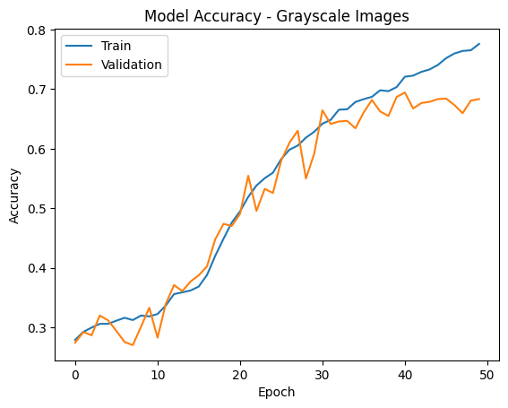

```python
#plot performance
plot_model(cnn_history_3b, 'GRAY')
```

```python
#test model
test_model(cnn_model_3b, 'GRAY')
```

```
{'happy': 0, 'sad': 1, 'neutral': 2, 'surprise': 3}
              precision    recall  f1-score   support

           0       0.81      0.73      0.77        30
           1       0.64      0.90      0.75        31
           2       0.69      0.65      0.67        31
           3       1.00      0.58      0.73        19

    accuracy                           0.73       111
   macro avg       0.79      0.72      0.73       111
weighted avg       0.76      0.73      0.73       111
```

**Observations: cnn_model_3b**

- with an accuracy of about 73% this is the best model yet!
- there is a notable divergence between the training and validation accuracies once the validation accuracy gets to about 70%. Once again the validation accuracy seems to be maxing out
- let's add even more to it and see if we can improve performance

#### **cnn_model_3c**

```python
def cnn_model_3c():
  model = Sequential()

  model.add(Conv2D(64, (2, 2), padding="same", input_shape = (48,48,1), activation = 'relu'))
  model.add(BatchNormalization())
  model.add(LeakyReLU(0.1))
  #model.add(MaxPooling2D(pool_size=(2, 2)))
  model.add(Dropout(.2))

  model.add(Conv2D(128, (2, 2), padding="same", activation = 'relu'))
  model.add(BatchNormalization())
  model.add(LeakyReLU(0.1))
 # model.add(MaxPooling2D(pool_size=(2, 2)))
  model.add(Dropout(.2))

  model.add(Conv2D(512, (2, 2), padding="same", activation = 'relu'))
  model.add(BatchNormalization())
  model.add(LeakyReLU(0.1))
  #model.add(MaxPooling2D(pool_size=(2, 2)))
  model.add(Dropout(.2))

  model.add(Conv2D(512, (2, 2), padding="same", activation = 'relu'))
  model.add(BatchNormalization())
  model.add(LeakyReLU(0.1))
  model.add(MaxPooling2D(pool_size=(2, 2)))
  model.add(Dropout(.2))

  #new layer
  model.add(Conv2D(1024, (2, 2), padding="same", activation = 'relu'))
  model.add(BatchNormalization())
  model.add(LeakyReLU(0.1))
  model.add(MaxPooling2D(pool_size=(2, 2)))
  model.add(Dropout(.2))

  # #new layer
  model.add(Conv2D(512, (2, 2), padding="same", activation = 'relu'))
  model.add(BatchNormalization())
  model.add(LeakyReLU(0.1))
  model.add(MaxPooling2D(pool_size=(2, 2)))
  model.add(Dropout(.2))

  model.add(Conv2D(128, (2, 2), padding="same", activation = 'relu'))
  model.add(BatchNormalization())
  model.add(LeakyReLU(0.1))
  model.add(MaxPooling2D(pool_size=(2, 2)))
  model.add(Dropout(.2))

  model.add(Flatten())

  model.add(Dense(256, activation = 'relu'))
  model.add(BatchNormalization())
  model.add(LeakyReLU(0.1))
  model.add(Dropout(.2))

  model.add(Dense(512, activation = 'relu'))
  model.add(BatchNormalization())
  model.add(LeakyReLU(0.1))
  model.add(Dropout(.2))

  model.add(Dense(512, activation = 'relu'))
  model.add(BatchNormalization())
  model.add(LeakyReLU(0.1))
  model.add(Dropout(.2))

  model.add(Dense(512, activation = 'relu'))
  model.add(BatchNormalization())
  model.add(LeakyReLU(0.1))
  model.add(Dropout(.2))

  #new layer
  model.add(Dense(1024, activation = 'relu'))
  model.add(BatchNormalization())
  model.add(LeakyReLU(0.1))
  model.add(Dropout(.2))

  #new layer
  model.add(Dense(1024, activation = 'relu'))
  model.add(BatchNormalization())
  model.add(LeakyReLU(0.1))
  model.add(Dropout(.2))

  #new layer
  model.add(Dense(1024, activation = 'relu'))
  model.add(BatchNormalization())
  model.add(LeakyReLU(0.1))
  model.add(Dropout(.2))

  model.add(Dense(512, activation = 'relu'))
  model.add(BatchNormalization())
  model.add(LeakyReLU(0.1))
  model.add(Dropout(.2))

  model.add(Dense(512, activation = 'relu'))
  model.add(BatchNormalization())
  model.add(LeakyReLU(0.1))
  model.add(Dropout(.2))

  model.add(Dense(512, activation = 'relu'))
  model.add(BatchNormalization())
  model.add(LeakyReLU(0.1))
  model.add(Dropout(.2))

  model.add(Dense(256, activation = 'relu'))
  model.add(BatchNormalization())
  model.add(LeakyReLU(0.1))
  model.add(Dropout(.2))

  model.add(Dense(4, activation='softmax'))


  # Compile model
  model.compile(loss = 'categorical_crossentropy',
              metrics = ['accuracy'],
              optimizer=tf.keras.optimizers.Adam(learning_rate=0.001))

  return model
```

```python
#load/compile model
cnn_model_3c = cnn_model_3c()
```

```python
#train model
cnn_history_3c = train_model(cnn_model_3c, 50, 'GRAY')
```

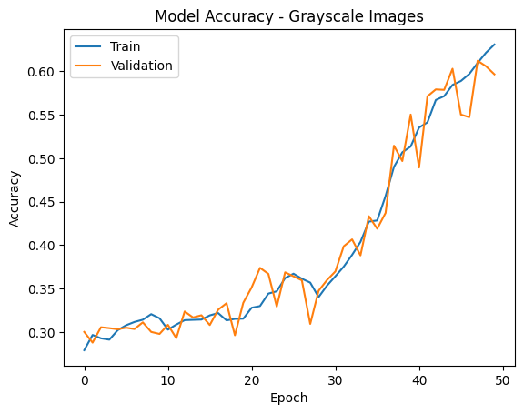

```python
#plot performance
plot_model(cnn_history_3c, 'GRAY')
```

```python
#test model
test_model(cnn_model_3c, 'GRAY')
```

```
{'happy': 0, 'sad': 1, 'neutral': 2, 'surprise': 3}
              precision    recall  f1-score   support

           0       0.68      0.77      0.72        30
           1       0.51      0.77      0.62        31
           2       0.57      0.39      0.46        31
           3       1.00      0.47      0.64        19

    accuracy                           0.61       111
   macro avg       0.69      0.60      0.61       111
weighted avg       0.66      0.61      0.61       111
```

**Observation:**

- cnn_model_3's accuracy is not as high as other models, but after 50 epochs it still seems to be learning
- Let's train the model over additional epochs to see if it improves accuracy

```python
# train a copy of the model in case additional epochs worsen performance
cnn_model_3c_gen2 = cnn_model_3c

#additional training epochs to try to squeeze out a little more accuracy
cnn_history_3c_gen2 = train_model(cnn_model_3c_gen2, 50, 'GRAY')
```

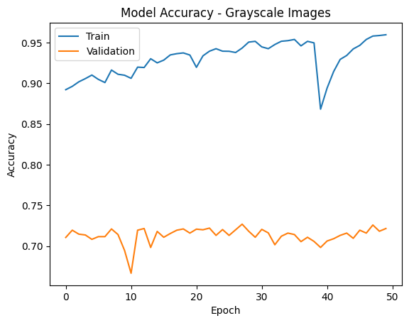

```python
#plot performance
plot_model(cnn_history_3c_gen2, 'GRAY')
```

```python
#test model
test_model(cnn_model_3c_gen2, 'GRAY')
```

```
{'happy': 0, 'sad': 1, 'neutral': 2, 'surprise': 3}
              precision    recall  f1-score   support

           0       0.84      0.87      0.85        30
           1       0.70      0.61      0.66        31
           2       0.59      0.71      0.65        31
           3       1.00      0.84      0.91        19

    accuracy                           0.75       111
   macro avg       0.78      0.76      0.77       111
weighted avg       0.76      0.75      0.75       111
```

## **Repurposing the architectures from the tranfer learning models**

```python
# define new base model - this is the base model from cnn_model_2b
def get_base_model_2():
  model = Sequential()
  model.add(Dense(256, activation = 'relu'))
  model.add(BatchNormalization())
  model.add(LeakyReLU(0.1))
  model.add(Dropout(.2))
  model.add(Dense(512, activation = 'relu'))
  model.add(BatchNormalization())
  model.add(LeakyReLU(0.1))
  model.add(Dropout(.2))
  model.add(Dense(512, activation = 'relu'))
  model.add(BatchNormalization())
  model.add(LeakyReLU(0.1))
  model.add(Dropout(.2))
  model.add(Dense(512, activation = 'relu'))
  model.add(BatchNormalization())
  model.add(LeakyReLU(0.1))
  model.add(Dropout(.2))
  model.add(Dense(512, activation = 'relu'))
  model.add(BatchNormalization())
  model.add(LeakyReLU(0.1))
  model.add(Dropout(.2))
  model.add(Dense(512, activation = 'relu'))
  model.add(BatchNormalization())
  model.add(LeakyReLU(0.1))
  model.add(Dropout(.2))
  model.add(Dense(512, activation = 'relu'))
  model.add(BatchNormalization())
  model.add(LeakyReLU(0.1))
  model.add(Dropout(.2))
  model.add(Dense(256, activation = 'relu'))
  model.add(BatchNormalization())
  model.add(LeakyReLU(0.1))
  model.add(Dropout(.2))
  model.add(Dense(4, activation='softmax'))

  return model
```

#### **Repurposing VGG16's Architecture**

```python
# import the model
imported_model_VGG16 = VGG16(weights='imagenet',include_top = False, input_shape = (48,48,3))

# Getting only the conv layers for transfer learning.
transfer_layer = imported_model_VGG16.get_layer('block5_pool')
vgg_conv_layers = Model(inputs=imported_model_VGG16.input, outputs=transfer_layer.output)

# make sure pre-trained layers WILL be trained on our data
vgg_conv_layers.trainable=True
```

```
Downloading data from https://storage.googleapis.com/tensorflow/keras-applications/vgg16/vgg16_weights_tf_dim_ordering_tf_kernels_notop.h5
```

```python
def cnn_model_VGG_2():
  # Intializing a sequential model
  model = Sequential()

  model.add(vgg_conv_layers)
  model.add(Flatten())

  ### BASE MODEL ###
  model.add(get_base_model_2())

  # Compile model
  model.compile(loss = 'categorical_crossentropy',
              metrics = ['accuracy'],
              optimizer=tf.keras.optimizers.Adam(learning_rate=0.001))

  return model
```

```python
#load/compile model
cnn_model_VGG_2 = cnn_model_VGG_2()

#train model
cnn_history_VGG_2 = train_model(cnn_model_VGG_2, 40, 'RGB')
```

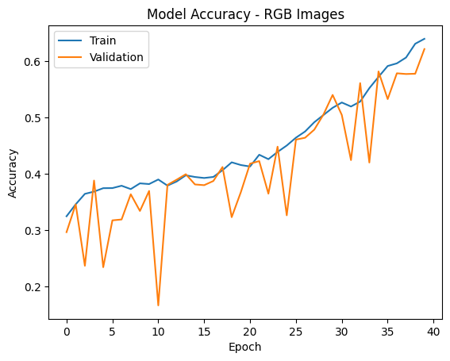

```python
# plot model performance
plot_model(cnn_history_VGG_2, 'RGB')
```

```python
#train model for an additional 40 epochs
cnn_history_VGG_2 = train_model(cnn_model_VGG_2, 40, 'RGB')
```

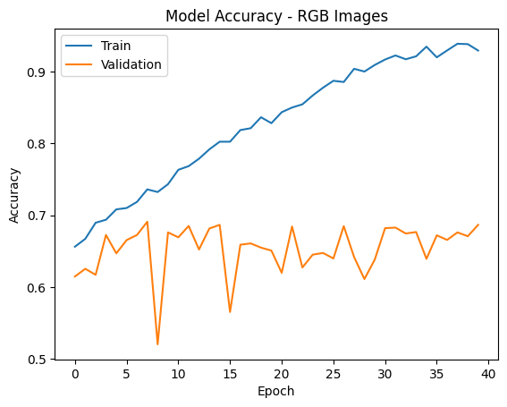

```python
# plot model performance
plot_model(cnn_history_VGG_2, 'RGB')
```

```python
#test model
test_model(cnn_model_VGG_2, 'RGB')
```

```
{'happy': 0, 'sad': 1, 'neutral': 2, 'surprise': 3}
              precision    recall  f1-score   support

           0       0.86      0.80      0.83        30
           1       0.63      0.61      0.62        31
           2       0.57      0.68      0.62        31
           3       0.94      0.79      0.86        19

    accuracy                           0.71       111
   macro avg       0.75      0.72      0.73       111
weighted avg       0.73      0.71      0.72       111
```

**Observations:** cnn_model_VGG_2

- this model has performed substantially better than the transfer learning version we used earlier
- the model exceeded 70% on the test data which puts in among our best models, but cnn_model_3c still has the highest accuracy so far